# DTS Stub

Ernesto

September 12, 2017

# 1 Introduction

We calibrate and validate the POSEIDON agent-based model to data from the US West Coast groundfish fishery and show how simple adaptive algorithms explain data better than perfect rationality. Moreover we show that while it is possible to derive statistical agents from logbook data, a simple, adaptive, uncalibrated decision-making algorithm performs just as well.

The present work has two main objectives. Fist, we would like to simulate fisheries for which we have no individual data on decision-making. Agent-based models commonly use statistics to bind how agents act: Saul (2012) uses logit regressions, Bastardie et al. (2013) uses decision trees and Shepperson et al. (2016) uses conjoint analysis. Often however we want to simulate scenarios for which this data either doesn’t exist (because it was never collected) or can’t exist (as when studying future shocks to regulation or biomass). Here we show that a simple exploration-imitation algorithm performs as well as statistical agents.

Our second, more general, objective is proving that the agent-based model POSEIDON, which has so far dealt only with theoretical problems, can be calibrated and validated with data. By calibration here we mean tuning parameters to minimize in-sample errors and by validation we mean observing out of sample prediction quality. We do understand that philosophically this is merely confirmation(Oreskes, Shrader-Frechette, and Belitz 1994).

There are two other bio-economic models of the US West Coast groundfish fishery. Kaplan, Holland, and Fulton (2014) is an Atlantis model (Fulton et al. 2011) of the entire ecosystem. Toft, Punt, and Little (2011) is a Deriso-Schnute two-species model (Dover sole and darkblotched rockfish). Biologically our model sits somewhere in between these two (we deal with 5 species, but ignore overall ecosystem effects). We focus more on the human side as we deal with individual boats rather than port groups. Focusing on the individual also allows us to calibrate against economic data (collected in Steiner et al. 2016).

We describe the fishery in section 2. We enumerate the components of our model in section 3. In section 4 we calibrate the model and in section 5 we test the calibration against withheld data. We test the sensitivity of the model to each component in section 6. Finally, we describe the elements that were not included in the model in section 7.

# 2 The Fishery

## 2.1 The DTS Fishery

The West Coast groundfish fishery is a multispecies fishery that lands over 90 species and has undergone significant management changes over the past 15 years. The fishery operates from southernmost California to northernmost Washington state in coastal waters mostly within 100km of shore. Species caught in the West Coast groundfish fishery are demersal (living near the bottom), primarily flatfish (e.g., sole), groundfish (e.g., sablefish, Anoplopoma fimbria), and rockfish (Sebastes sp.). Primary target species are petrale (Eopsetta jordani) and Dover sole (Solea solea), shortspine (Sebastolobus alascanus) and longspine (Sebastolobus altivelis), thornyheads, arrowtooth flounder (Atheresthes stomias), and Pacific hake (a.k.a. whiting, Merluccius productus) (S. J. Miller and Deacon 2017), though Pacific hake (as well as Pacific halibut) is mostly part of a separate fishery (Bellman and Heery 2013).

The species composition of catch is strongly related to fishing grounds. Ocean depth and demersal habitat type (e.g., rock, mud, sand, gravel) are major drivers of the species composition. The vast majority of the catch in the west coast groundfish fishery comes from trawl gear, which is largely indiscriminate within its spatial and temporal tow-path and depth stratum (Bellman and Heery 2013). A few vessels use ‘fixed gears’ (e.g., hook and line, pots and traps), which are more selective (S. J. Miller and Deacon 2017).

The West Coast groundfish fishery is an ideal validation setting because it is relatively data rich and has a diverse management history, which includes spatial and temporal closures, gear restrictions, limits on entry, and most recently, individual fishing quotas (IFQs–almost identical to individual tradeable quotas, or ITQs; S. J. Miller and Deacon 2017 explain the subtle differences, which are related to how quotas can be transferred).

The U.S. government declared the West Coast groundfish fishery an economic disaster in 2000, and the Pacific Fishery Management Council implemented a gear restriction (on trawl footrope sizes) to protect rocky habitats (Bellman, Heppell, and Goldfinger 2005). In 2003, the U.S. government began vessel buyback programs to reduce fishing capacity (S. J. Miller and Deacon 2017), and the rockfish conservation areas (RCAs) were established to reduce bycatch of overfished species (particularly darkblotched [Sebastes crameri] and canary rockfish [Sebastes pinniger]). The RCA boundaries shift within and across years, but generally close the shelf from 100-250m isobaths along the entire West Coast to trawl gear. Selective flatfish gear is required shoreward of the RCA boundary (reduces catch of rockfish). In 2011, the fishery transitioned to multispecies Individual Fishing Quotas (IFQs)–a catch-share program–leaving the RCAs in place. This policy change allocated the coast-wide catch limits for each species among individual vessel owners, and required 100 percent observer coverage.

We focus on 5 species, belonging to the fishery segment targeting ‘DTS’ (dover sole-thornyhead-sablefish’). Dover sole, sablefish, longspine thornyhead and shortspine thornyhead made up over 40% of the annual revenue from the groundfish fishery. We focused on these four species plus another bycatch species, yelloweye rockfish, because of its historically high level of depletion, overfishing and the small amount of quota available for it.

## 2.2 Data Available

The DTS (Dover-thornyhead-sablefish) fishery we study is data rich. We use biological and fleet data to parametrize the model while we use data on fishing decisions and outcome to calibrate and validate it.

We parametrize the biological layer in section 3.1. Its two main sources are the stock assessment models produced by the the Pacific Fishery Management Council(Stewart, Thorson, and Wetzel 2011; Taylor and Wetzel 2011; Taylor and Stephens 2013; Stephens and Taylor 2013; Hicks and Wetzel 2011) and suitability maps of the California Current produced as part of the Essential Fish Habitat synthesis(National Marine Fisheries Service 2013).  
We parametrize the fleet in section 3.2. Its main source is the catcher vessel report (Steiner et al. 2016) including data from its website (Northwest Fisheries Science Center 2017) and bespoke data requests.

We describe the fishing outcomes we calibrated against in section 2.2.2. These combine quota attainment rate and landing observations (Somers et al. 2016; National Marine Fisheries Service 2017), but include also more observations from the catcher vessel report and aggregate trip information from the logbook data. We calibrated fishing decisions against logbook data for all boats in California and Oregon between 2011 and 2014 as shown in section 2.2.1.

### 2.2.1 Fishing Decisions

Logbook data contains the length, duration, catch and location of each trip made by each boat from California and Oregon. We condense this large set of observations into a few key metrics. The fewer and more informative these metrics are, the easier our calibration in section 4. We obtain these metrics by fitting a discrete choice model to the logbook dataset.

Discrete choice models are often used in fisheries management to study why and how captains choose where to fish (Holland and Sutinen 2000; Len M Hunt 2005; Len M. Hunt, Boots, and Boxall 2007; Abbott and Wilen 2011). We first impose a grid of “statistical areas” over the California current, each one degree latitude by one degree longitude as shown in figure 2.1. We then fit a logistic regression that predicts which statistical area each fisher goes to next given its history.

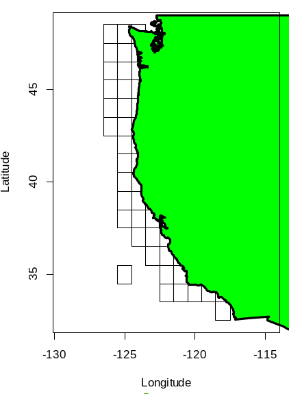

Figure 2.1: Map of defined statistical areas off the West Coast of the United States, which represent discrete fishing location choices in the revealed preference panel dataset, and in the output of the POSEIDON model application to the West Coast groundfish fishery.

We fit our logistic regression using only 2 variables (excluding intercepts): habit (times each area was visited in the past year) and distance from port.  
We chose this model for three reason. First, we were looking the statistical model with as few parameters as possible as it makes calibration easier. Second, the regression has a in-sample success rate of 72% (i.e. probability of predicting correctly which of the 32 statistical areas the fisher will go next) already with two parameters. Third, the very high habit coefficient summarises the key dynamic of the fishery: agents often return to the same statistical area.

Table 2.1 shows the coefficients of the logistic regression. All intercepts except one are insignificant (and the significant effect size is small compared to habit and distance). The farther an area the less likely it will be chosen, while areas that have been visited before are more likely to be chosen again. We use these parameters to calibrate our agents in section 4.

Table 2.1: Multinomial site choice model $\beta$ for all trips from 2012 (trips in 2011 used to initialize the habit parameter). `Distance` is the kilometers between port and center of statistical area. `Habit` is number of trips in the same area in the past 365 days. Bolded are the coefficients that are significant.

| Parameter | Estimate | Std. Error | t-value | Pr(> |
| --- | --- | --- | --- | --- |
| **Distance** | -0.021 | 0.001 | -15.094 | <0.001 |
| **Habit** | 0.213 | 0.013 | 16.261 | <0.001 |
| 51:(intercept) | -0.029 | 0.639 | -0.045 | 0.964 |
| **61:(intercept)** | 1.983 | 0.576 | 3.443 | 0.001 |
| 62:(intercept) | 0.953 | 0.529 | 1.801 | 0.072 |
| 63:(intercept) | 0.509 | 0.476 | 1.071 | 0.284 |
| 73:(intercept) | -16.018 | 5752.487 | -0.003 | 0.998 |
| 85:(intercept) | 0.825 | 3.966 | 0.208 | 0.835 |
| 86:(intercept) | -16.758 | 5682.723 | -0.003 | 0.998 |
| 97:(intercept) | 2.226 | 3.964 | 0.561 | 0.574 |
| 98:(intercept) | -0.138 | 3.997 | -0.035 | 0.972 |
| 109:(intercept) | -16.328 | 6539.433 | -0.002 | 0.998 |
| 110:(intercept) | 1.869 | 3.984 | 0.469 | 0.639 |
| 122:(intercept) | 1.802 | 4.103 | 0.439 | 0.66 |
| 134:(intercept) | 2.693 | 4.121 | 0.653 | 0.513 |
| 135:(intercept) | 1.959 | 4.107 | 0.477 | 0.633 |
| 147:(intercept) | 3.035 | 4.117 | 0.737 | 0.461 |
| 148:(intercept) | 2.434 | 4.116 | 0.591 | 0.554 |
| 160:(intercept) | 2.842 | 4.135 | 0.687 | 0.492 |
| 161:(intercept) | -0.115 | 4.246 | -0.027 | 0.978 |
| 173:(intercept) | 3.614 | 4.143 | 0.872 | 0.383 |
| 174:(intercept) | 1.706 | 4.152 | 0.411 | 0.681 |
| 186:(intercept) | 3.105 | 4.147 | 0.749 | 0.454 |
| 187:(intercept) | 1.335 | 4.155 | 0.321 | 0.748 |
| 198:(intercept) | -17.351 | 7252.268 | -0.002 | 0.998 |
| 199:(intercept) | 2.59 | 4.148 | 0.624 | 0.532 |
| 200:(intercept) | 1.068 | 4.149 | 0.258 | 0.797 |
| 212:(intercept) | 1.497 | 4.151 | 0.361 | 0.718 |
| 213:(intercept) | -0.74 | 4.163 | -0.178 | 0.859 |
| 225:(intercept) | 2.388 | 4.154 | 0.575 | 0.565 |
| 226:(intercept) | -18.703 | 6210.947 | -0.003 | 0.998 |
| 237:(intercept) | -15.193 | 6316.336 | -0.002 | 0.998 |
| 238:(intercept) | 3.905 | 4.162 | 0.938 | 0.348 |

### 2.2.2 Fishing Outcomes

Besides reproducing choices observed, we’d like our model to also reproduce correctly the consequences of those choices. Table 2.2 lists the aggregate observations about the fishery we want our model to reproduce. Notice that while the empirical mean cited refers to the period 2011-2014, the standard deviation refers to the between years standard deviations (as we obviously have only one possible observation of the 2011-2014 mean). To use Grimm et al. (2005) terminology, these are the patterns we would like our model to replicate.

Table 2.2: All the aggregate observations we would like our model to be able to predict. All means refer to the period 2011-2014. All standard deviations are the empirical deviations of the yearly mean observed, except for the data derived from the logbook data where we are using the standard deviation of the whole sample.

| Measure | Empirical Mean | Empirical Standard Deviation | Source |
| --- | --- | --- | --- |
| Boat Yearly Profits ($) | 89,308.90 | 21,331.00 | Steiner et al. (2016) |
| Yearly Hours Out | 999.936 | 120 | Steiner et al. (2016) |
| Sole Quota Attainment | 33.25% | 3.09% | Somers et al. (2016) |
| Sablefish Quota Attainment | 83.65% | 6.18% | Somers et al. (2016) |
| Shortspine Quota Attainment | 52.50% | 5.00% | Somers et al. (2016) |
| Longspine Quota Attainment | 51.50% | 5.00% | Somers et al. (2016) |
| Yelloweye Quota Attainment | 7.00% | 2.00% | Somers et al. (2016) |
| Trip Duration (hr) | 69.1 | 33 | Logbook |
| Distance port to 1st trawl (km) | 90.89 | 32 | Logbook |

# 3 Model

## 3.1 Biology and Geography

The model runs over a grid 50 cells wide and 120 cells across. Each cell is a square of size 15.16km. The top left cell of the map is off Washington coast on the border with Canada (lat: 48.194, long: -125.878), the bottom right cell is on the Californian sea border with Mexico (lat: 32.017, long:-117.403). Distances between cells are Cartesian over their UTM 10 coordinates.

We model 5 species of fish: Dover sole (Solea solea), shortspine thornyhead (Sebastolobus alascanus), longspine thornyhead (Sebastolobus altivelis), sablefish (Anoplopoma fimbria) and yelloweye rockfish (Sebastes ruberrimus). The first four form the main target species of the DTS (Dover-thornyhead-sablefish) fishery. Yelloweye rockfish is a by-catch for which only few quotas are available.

The model tracks the number of fish per cell, per species, per age and per sex. Each cell of the map (excluding land ones) contains a set of abundance vectors $\Big\{ A_{1,\text{male}},A_{1,\text{female}},A_{2,\text{male}},\dots,A_{5,\text{female}} \Big\}$ where:
$$A_{i,\text{male}} =
\begin{bmatrix}
\text{No. of male fish of species } i \text{ of age } 0\\
\text{No. of male fish of species } i \text{ of age } 1\\
\vdots\\
\text{No. of male fish of species } i \text{ of max age}_i\\
\end{bmatrix}$$

Coast-wide abundance comes from stock assessment models. We populate each cell by distributing coast-wide abundance in proportion to the relative cell abundance predicted by the Essential Fish Habitat synthesis effort (National Marine Fisheries Service 2013). These abundance maps were generated by fitting spatio-temporal models to the NWFSC groundfish trawl survey data from 2003-2011 (Shelton et al. 2014).

We assume that all fish in the same age and sex bin are of the same weight and length. We compute length at age $a$ by
$$L_a = L_{\infty} \big( 1 - e^{-k (a - a_0)} \big)$$
We convert length to weight by:
$$W = \alpha L^\beta$$
Length and weight parameters are different for each species and each sex.

Through the weight vector $W$ we can compute the spawning stock biomass ($SS$) for each species as:
$$SS_i = W_{i,\text{female}}^T \left( M_{i} \circ A_{i,\text{female}} \right)$$
Where $M_i$ is the vector of maturity for each age bin and $\circ$ is the Hadamard (element-wise) product. We compute maturity as a function of length $l$ as:
$$M(l) = \frac{1}{1 + e^{-\gamma ( l - L_{50})}}$$
Where $L_{50}$ is the inflection point and $\gamma$ is the slope of the maturity curve and differ for each species.

Four events modify cell abundance: recruitment, ageing, natural mortality and fishing mortality. Fishing mortality is driven by the fleet component of the model. Recruitment, ageing and natural mortality are global, deterministic and yearly events. Mathematically we update each element of each abundance vector as follows:
$$\text{No. of fish of species } i \text{ of max age}_i = \begin{cases}
R & \text{ if } a = 0 \\
e^{-z} \left(\text{No. of fish of species } i \text{ of age } a-1 \right) & \text{ if } 0 < a <= \text{max age} \\
0 & \text{ if } a > \text{max age}
\end{cases}$$
Where $R$ is the number of recruits each year and $z$ is the yearly mortality rate.

Recruitment follows the Beverton-Holt form, parametrized in terms of steepness ($h$), unfished recruitment ($R_0$), recruitment potential ($\phi$) and spawning stock biomass ($\text{SS}$)
$$R = \frac{4 h R_0 {SS}}{R_0 \phi (1-h) + (5h-1){SS}}$$
We aggregate each cell’s spawning stock biomass ($SS$) into a single coast-wide stock before computing the number of yearly recruits. We assume half of the recruits are male. We distribute recruits in each cell proportional to the original allocation of abundance at the beginning of the simulation.

We model no predator-prey interaction between fish. We coded movement but we found its effect negligible on the outcome of the model. Because movement proved taxing to the speed of the simulation we then turned it off. We describe its equations and effects in the sensitivity analysis part of the paper in section 6.5. Sablefish is targeted by other fisheries in the California Current besides the one studied here. To simulate this, at the end of each year each cell is targeted at random until the empirical catches from these fisheries are achieved. This allows us to integrate exogenous fishing mortality without modelling explicitly the boats that caused it.

## 3.2 Fleet

We simulate the 90 trawlers of the West Coast DTS (Dover-thornyhead-sablefish) fishery. They are distributed by port according to the 2010 census available from the Northwest Fisheries Science Center’s catcher vessel report (Steiner et al. 2016). The north-most port is Seattle, the south-most port is Monterey.  
We assume the fleet homogeneous in terms of quota allocation, hold-size and fishing ability.

A boat fishing for one hour, catches a set of vectors $x_1,\dots,x_n$ determined by:
$$x_i = q_i \left( s_i \circ r_i \circ A_i \right)$$
$$x_i = \begin{bmatrix}
\text{No. of fish caught of species } i \text{ of age } 0\\
\text{No. of fish caught of species } i \text{ of age } 1\\
\vdots\\
\text{No. of fish caught of species } i \text{ of max age }\\
\end{bmatrix} = q_i \cdot
\begin{bmatrix}
r_{i,0}s_{i,0} A_{i,0}\\
r_{i,1}s_{i,1} A_{i,1}\\
\vdots\\
r_{i,\text{max}}s_{i,\text{max}} A_{i,\text{max}}\\
\end{bmatrix}$$
Where $q_i$ is the catchability scalar for species $i$, $s_i$ is the selectivity vector, $r_i$ is the retention vector, $A_i$ is the number of fish per age bin in the cell being fished and $\circ$ is the Hadamard (element-wise) product.
The selectivity ($s_i$) and retention ($r_i$) vectors are fixed to the stock assessment values; the abundance vector ($A_i$) is a simulation’s state variable and the catchability scalar $q_i$ is a free parameter. Stock assessments have their own catchability parameter but we ignore them. This is because the stock assessment’s catchability refers to the probability of the catching each fish in the ocean while in our model it refers to the probability of catching only the fish within the cell being trawled.

Boats sell fish by weight and the price is fixed to the average prices observed between 2011-2014. We assume sale prices constant between ports. Table 3.1 shows the ex vessel price per kg landed. Notice that sablefish price does not include fixed gear premiums that are usually paid to other west coast boats targeting sablefish that are not part of the DTS fishery. Besides the five species studied, trawlers in the DTS fishery often catch many other species in small amounts. Parametrizing against catcher-vessel data, each simulated trawl contains 32.21% of the catch (by weight) as “miscellaneous” catch. This catch is also sold at port using its weighted average sale price observed in the 2011-2014 period.

Table 3.1: The ex vessel price (that is the price paid to a boat when landing fish) in the model.

| Species Landed | Ex Vessel Price ($/kg) |
| --- | --- |
| Dover Sole | 0.67 |
| Sablefish | 4.32 |
| Shortspine | 1.04 |
| Longspine | 1.04 |
| Yelloweye | 1.08 |
| Miscellaneous | 1.76 |

Lian, Singh, and Weninger (2009) computed the physical limits for groundfish trawlers on the west coast to be 170 days at sea. This implicitly accounts both for repairs, weather conditions and fishing seasonality. Most DTS fishermen also participate in the shrimp fishery for an average of 50 days a year. In our model then, each boat can only be at sea for 120 days.  
Each trip fishers trawl a target cell until their hold is full or 6 days have passed.

Each boat moves at 16 kph and consumes 3.54 l/km of gas when moving and 57l each hour spent fishing (using Toft, Punt, and Little (2011) estimates). Gas price changes yearly and is fixed to the average yearly price observed in California each year. Gas costs the same in each port. On top of fuel expenditures, each hour at sea costs a boat 165$ (including crew and captain fees). A boat that makes two years of consecutive losses quits the fishery. Boats that quit still own yearly quotas and can lease them to active fishers.

Fishers are subject to 2 set of regulations from 2011: Rockfish Conservation Areas and individual tradeable quotas. When we simulate fishing before 2011, fishers are subject to the Rockfish Conservation Areas and bi-monthly trip limits.

Rockfish Conservation Areas are areas of the sea around the coast where fishing is not allowed . We simplify their boundaries by assuming they cover every cell of the map with depth of 200m or less. In reality boundaries varied slightly year to year but the model resolution is coarse enough that this has no effect.

From 2011 each year each fisher is given a set of quotas. The quota represents the maximum weight of each species that a fisher can land that year. Fishers can rent or lease quotas to one another. Fishers that run out of one quota are not allowed at sea until the next year. The quota market functions as an order book: each day it reveals bid and ask prices for each quota from each fisher and matches crossing orders until every feasible trade occurs (always at the ask price). Expectations and reservation prices update as described in the original appendix of POSEIDON. The aggregate quota available is fixed at the average 2011-2014 observations summarised in table 3.2. In reality sablefish quotas are split in two markets north and south of the 36N parallel. We assumed a unified market here, but we test this assumption during sensitivity analysis in section 6.4.

Table 3.2: Yearly quotas to be shared among fishers each year.

| Species | Yearly Quota (mt) |
| --- | --- |
| Dover Sole | 22,234.5 |
| Sablefish | 2,724.9 |
| Shortspine | 1,4816 |
| Longspine | 1,966.25 |
| Yelloweye | 0.6 |

Table 3.2: Yearly non-tradeable quotas to be shared among fishers each year pre-2011.

| Species | Yearly Quota (mt) |
| --- | --- |
| Dover Sole | 16,866 |
| Sablefish | 3,457.8 |
| Shortspine | 1,927.8 |
| Longspine | 2,577.6 |
| Yelloweye | 67.1 |

## 3.3 Decision-Making

Fishers need to choose which cell to trawl each trip, we propose here multiple algorithms to do so. We assume all fishers are profit maximizers. The algorithms define how they go about maximizing profits, that is we model the procedural rationality of the agents (Simon 1997); think more stochasts versus cartesians(P. M. Allen and McGlade 1986) rather than quantity versus quality maximizers(Shepperson et al. 2016).

We present 8 different algorithms here. Two of them (*logit* and *locked*) are statistical: we use real logbook data to simulate how people actually acted. Four of them (*bandit*, *social annealing*, *explore-exploit-imitate* and *heatmapping* ) are simple adaptive agents, starting with no information. *Random* agents are useful as a baseline to compare other algorithms. *Perfect* agents, the usual assumption in bio-economic models (including Kaplan, Holland, and Fulton 2014 ), know the location of all the fish in the simulation.

All algorithms automatically avoid cells that are protected (the fishery has 100% observer coverage) and cells that can never hold fish (these are cells where the Essential Fish Habitat maps assigned 0 abundance).  
All model runs have one initialization year: agents fish for a year following all the proper regulations, after which the biology layer is resetted and the real model run starts.

### 3.3.1 Logit Agents

Logit agents use the discrete choice model fit from section 2.2.1 to pick which statistical area to trawl next.
More precisely, given a vector of logit coefficients $\beta$ and the design matrix $X$ where each row $x_i$ contains the observations regarding statistical area $i$, the probability of fishing in statistical area $i$ is:
$$\text{Pr}(i) = \frac{e^{x_i \beta}}{ \sum_{j} e^{x_j \beta}}$$
Once a statistical area is picked, a cell at random within that area is trawled

Expressed in pseudo-R, logit agents act as follows:

```r
# Given K statistical areas
# Logit coefficients beta
# And observations (distance, habit and intercepts) for each area

#compute utility (logits)
for(statistical_area in 1:K)
  utility[statistical_area] = beta*observations[statistical_area,]

# Use SOFTMAX to pick one statistical area:
# probability of choosing arm i is proportional to the exp of its utility
denominator<- sum(exp(utility))
probabilities<- exp(utility)/denominator
# choose statistical area based on that probability
statistical_area<-sample(1:K,prob = probabilities,size = 1)
# target a random cell in that statistical area
target<-sample(cells[statistical_area],size=1)
```

This is the standard way to simulate historical behaviour in fishery agent-based models (see for example Saul 2012; K. A. Rose et al. 2015). Because its $\beta$ vector comes from a statistical fit, it requires no further calibration.

### 3.3.2 Statistically Locked Agents

Statistically locked agents are a less elegant (but more effective) way to force agents to act historically. Agents only consider statistical areas within 200km of their home port. They target each area with probability proportional to how often that area was visited between 2011 to 2014. For example, if the agent has to choose between statistical area *A* and *B*, and the logbook data shows that area *A* was visited 900 times while area *B* 100 times then the agent will visit *A* with probability $\frac{9}{10}$.

Expressed more precisely in algorithm form:

```r
# Given K statistical areas
# given trips[] vector containing empirically observed visits per statistical area

#ignore all areas that are too far
for(statistical_area in 1:K)
  if(distance(statistical_area) > 200)
     trips[statistical_area] = 0

# normalize trips into probabilities
trips<- trips/sum(trips)
# choose statistical area based on that probability
statistical_area<-sample(1:K,prob = trips,size = 1)
# target a random cell in that statistical area
target<-sample(cells[statistical_area],size=1)
```

If we judge statistical accuracy in terms of how much each statistical area was visited between 2011 and 2014, then the statistical locked agent is more accurate than the logit one. This is because logit agents have a high $\beta$ associated with “habit” variable and tend to often get stuck in suboptimal areas. When we judge statistical accuracy by random utility choice fits, then the logit agents are more accurate than the statistical locked ones.  
Statistically locked agents then look more accurate in aggregate but less so when studying their individual dynamics.

### 3.3.3 Bandit Agents

The multi-armed bandit problem (Bubeck and Cesa-Bianchi 2012; Kuleshov and Precup 2014; Vermorel and Mohri 2005) is a classic model of the exploration-exploitation tradeoff. In its original form an agent faces a set of slot machines; each slot machine’s payoff is stochastic but some machines are better than others. The agent can only play one slot machine at a time and has to balance the need to try new slot machines to learn their payoffs with the cost of not playing the slot machine that so far has proven superior.  
Many heuristics, bandit algorithms, have been proposed to solve this class of problem but here we focus only on the simplest one: the $\epsilon$ greedy bandit.

Each trip the agent has probability $\epsilon$ of trying a statistical area at random. If not the agent will go back fishing the area whose average profits have been highest so far. At the end of each trip, the agent observes the profits made and updates its valuation of the statistical area visited. More precisely, the algorithm proceeds as follows:

```r
# Given K statistical areas
# given experience[] vector containing average profits observed so far by the agent

# with probability epsilon, make random choice
if(runif() < epsilon)
    chosen_area <- sample(1:K,size=1)
# otherwise pick the area that so far made the most profits
else
    chosen_area<-which.max(experience)

target<-sample(cells[chosen_area],size=1)

# at the end of the trip, update your experience by
# exponential moving average
experience[chosen_area]<- alpha * experience[chosen_area] + (1-alpha) * profits_made
```

The algorithm has 2 parameters: the exploration rate $\epsilon$ and the exponential moving average’s smoothing parameter $\alpha$.

### 3.3.4 Social Annealing Agents

Social annealing agents use slightly more information than bandit algorithms because they know the coast-wide average profit per trip made. Whenever an agent is doing $k$% worse than average, she explores a new cell. Otherwise she targets to the last cell visited.

More precisely, the algorithm proceeds as follows:

```r
# knowing last_cell_visited as the cell targeted in last trip

# if you are making less than k times the average
if(profit_made < k * average_profits)
  # pick a new area at random in the neighborhood of your last cell visited
  # where delta is the exploration range
  options<- von_neumann_neighborhood(last_cell_visited,
                                     delta)
  #go there
  target<-sample(options,size=1)
else
  #otherwise keep fishing in the same spot
  target<-last_cell_visited
```

The algorithm depends on two parameters: the threshold parameter $k$ and the exploration range (in map cells) $\delta$. This algorithm first appeared (with $\delta=\infty$), to the best of our knowledge, in Beecham and Engelhard (2007).

### 3.3.5 Explore-Exploit-Imitate Agents

Explore-exploit-imitate is the default algorithm in POSEIDON. Much like the $\epsilon$-greedy algorithm, it has a fixed probability of exploring a new cell (although in this instance the exploration is in the neighborhood of the last cell visited, not a random new statistical area).  
When not exploring, the agent has a probability of imitating a “friend” who is making more money. Otherwise the fisher targets the last cell trawled.

Each fisher has 2 “friends” she keeps track of. Each fisher knows where their friends last trip was and how much money it made. Friendship is only possible between boats of the same port. Friendships are not necessarilly reciprocal (more precisely, the friendship network is a random constant outdegree network).

In pseudo-R the explore-exploit-imitate algorithm looks as follows:

```r
# with probability epsilon, explore
if(runif()<epsilon)
  # pick a new area at random in the neighborhood of your last cell visited
  # where delta is the exploration range
  options<- von_neumann_neighborhood(last_cell_visited,
                                     delta)
  #go there
  target<-sample(options,size=1)
else
  # if a friend is doing better, target their area with probability gamma
  if(runif < gamma && profits[me] < profits[best_friend])
    target<- position[best_friend]
  # otherwise go back to the same cell
  else
    target<-last_cell_visited


#if explored and the profits are worse than before, then go back
if(profits(last_cell_visited)<profits(cell_visited_two_trips_ago))
  last_cell_visited<-cell_visited_two_trips_ago
```

The algorithm depends on 3 parameters: the exploration rate $\epsilon$, the exploration range $\delta$ and the imitation probability $\gamma$.

### 3.3.6 Heatmapping Agents

Heatmapping agents build a statistical model of profit per cell (the eponymous heatmaps) and update it and the end of each trip. With a fixed probability $1-\epsilon$ they target the peak of the heatmap otherwise fishing in its neighborhood.

More precisely the heatmapping agent builds a statistical heatmap by using a kernel regression where for each cell $x$ we initialize variables $g_0,m_0=0$.
Whenever the fisher observes profits $\Pi_y$ at cell $y$, it updates its estimate profitability of cell $x$ by:
$$\begin{aligned}
g_n &= g_{n-1} + K(x,y) \\
m_n &= m_{n-1} + \frac{ \left(\Pi_y - m_{n-1} \right) K(x,y)}{g_n}
\end{aligned}$$
Where $K(\cdot,\cdot)$ is a kernel function and $m_n$ is the predicted profitability of $x$.
To give more weight to more recent observations we add a forgetting factor $0<\lambda<1$ as follows:
$$g_n = \lambda g_{n-1} + K(x,x_n)$$
We use here as kernel function:
$$K(x,y) = exp(-\frac{\text{Distance}(x,y)^2}{2\sigma})$$
Where $\sigma$ is the space bandwitdh (that is, it modulates how much far away observations affect profitability predictions here).
This recursive version of the Kernel regression first appeared in Krzyzak (1992).

Given the statistical model, the heatmapping agents proceed as follows:

```r
# given heatmap_predictions: the predictions made by the fisher about each cell profitability
best_cell<-which.max(heatmap_predictions)
# with probability epsilon, explore around the best_cell
if(runif()<epsilon)
  # where delta is the exploration range
  options<- von_neumann_neighborhood(best_cell,
                                     delta)
  #go there
  target<-sample(options,size=1)
else
  # pick the top
  target<-best_cell
```

It is the strategy with more parameters to calibrate: $\delta$ is the exploration range, $\epsilon$ is the exploration probability, $\sigma$ is the space bandwitdh, $\lambda$ is the forgetting factor.

### 3.3.7 Random Agents

Random agent simply pick a cell at random each trip. It is a very poor strategy but it is important to use as a baseline: if other algorithms’ performance equals the random agents’ one then those algorithms aren’t useful. They have no parameters to calibrate

### 3.3.8 Perfect Agents

Perfect agents pick a random cell for each statistical area, compute the profitability for each of those cells and pick one in proportion to the exponential of the expected profits (like logit agents). The agent has perfect knowledge in the sense that it knows ahead of time the profits she will make for each cell. However the agent does not update its computation halfway through a trip. This means that if multiple perfect agents target the same cell, their profits might be lower than expected at the beginning of the trip. These agents do not have the infinite computational power needed to analyse the game theoretical implications of everyone else being as informed as they do.

More precisely, perfect agents act as follows:

```r
# given K statistical areas

#pick a cell for each area
for(statistical_area in 1:K)
  cell[statistical_area]<-sample(cells[statistical_area],size=1)
  #compute profits for each cell
  profits[statistical_area]<-forecast_profits(cell)

# Use SOFTMAX to pick one statistical area
denominator<- sum(exp(profits))
# probability of choosing arm i is proportional to the exp of its utility
probabilities<- exp(profits)/denominator
# choose statistical area based on that probability
statistical_area<-sample(1:K,prob = probabilities,size = 1)
# target selected cell in that statistical area
target<-cell[statistical_area]
```

# 4 Calibration

Calibration means model fitting: change parameters to minimise the distance between model output and real data. The model has 6 non-behavioural parameters: a vector of catchabilities $Q= \left(\begin{smallmatrix}q_{\text{sablefish}} & q_{\text{sole}} & q_{\text{shortspine}} & q_{\text{longspine}} & q_{\text{yelloweye}}\end{smallmatrix}\right)$ and the maximum hold $H$ size of each boat. Some decision-making algorithms have additional parameters to tune (listed in section 3.3).

We build two aggregate error measures to define the distance between model and real data: the logbook and the outcome error.
The logbook error is the difference between the $\beta$ we obtain from fitting a discrete choice model to the real logbook and the $\beta$ we obtain from fitting the synthetic logbook data generated by our agent-based model. More precisely the logbook error is:
$$\text{Logbook Error} = \sum_i \frac{|\beta_i - \hat \beta_i|}{\sigma_i}$$
Where $\beta$ are the real habit and distance coefficients from table 2.1, and $\hat \beta$ come from fitting the agent-based model’s logbook; $\sigma_i$ is the standard error of each coefficient.

Minimizing the logbook error is an example of indirect inference(Gourieroux, Monfort, and Renault 1993). It involves fitting a statistical (“auxiliary”) model to both real and simulated data and use the two fits to judge the distance between them. Here the auxiliary model is the discrete choice model. Indirect inference has been applied to agent-based models in the past, particularly for financial and economic simulations (Richiardi et al. 2006; Zhao 2010). An idiosyncratic version of indirect inference is present in the fishery model by Cenek and Franklin (2017) where the authors use linear regressions as auxiliary models.  
To the best of our knowledge indirect inference by discrete choice model has never been done in spite of this being a very straightforward solution to the issue of comparing simulated and empirical maps (see section 6 of Stow et al. 2009 where the $\beta$ of our auxiliary model can be understood as just another higher order spatial feature).

The outcome error is the difference between the observed fishing outcomes summarised in table 2.2 and the fishing outcomes generated by the agent-based model. More precisely the error is defined as:
$$\text{Outcome Error} = \sum_i \frac{|y_i - \hat y_i|}{\sigma_i}$$
where $y_i$ is the empirical mean of a fishing outcome, $\sigma_i$ is its standard deviation and $\hat y_i$ is a simulated fishing outcome.

The weakness of this approach is that it implicitly weighs some features more than others. Because landings data have lower variation coefficients than profits, we penalize prediction errors in landings more than in profits. Moreover, because our landings are defined in terms of quota attainment and percentage points, we value accuracy in yelloweye attainment (for which less than a ton of quota is available each year) just as much as sablefish accuracy (the main target species).  
This is however an unavoidable consequence of aggregating multiple patterns into a single error number (Badham et al. 2017).

We calibrate our model in two steps.  
First, using statistically locked agents (agents that are forced to go where boats empirically fished, see section 3.3.2), we calibrate the catchability vector $Q$ and the hold size $H$ by minimizing the outcome error.  
Second, given the catchability and hold size from step one, we calibrate each decision-making algorithm separately by minimizing the logbook error.

We minimize the errors in each step by using a Bayesian optimiser (Shahriari et al. 2016; Snoek, Larochelle, and Adams 2012). In essence this is an evolution of the BACCO (Bayesian analysis of computer code output) techniques that are popular in environmental agent-based models (Parry et al. 2013; O’Hagan 2006; Uusitalo et al. 2015). Both techniques involve building a statistical emulator (a meta-model) to predict the output of the agent-based model without actually running it. The difference is that in BACCO this is done by running all the simulations at once (usually along a latin hypercube), train the emulator and then using it; a Bayesian optimizater instead iteratively runs the agent-based model once, re-trains the emulator and runs the agent-based model again around where the emulator thinks the peak output is. Rather than exploring the whole input space, the Bayesian optimiser only samples from the promising areas.

An optimiser calibrates the model efficiently but stresses the implicit weighing due to error aggregation. That is, the optimiser trades large increases in error for variables with high $\sigma$ in exchange for minor improvements in variables with lower standard deviations. This problem can be alleviated somewhat by plotting each fishing outcome separately when looking at simulation outputs.  
For example, figure 4.1 shows 100 simulations after completing the first step of the calibration, while figure 4.2 shows the same plot after finishing the calibration of the explore-exploit-imitate agent.

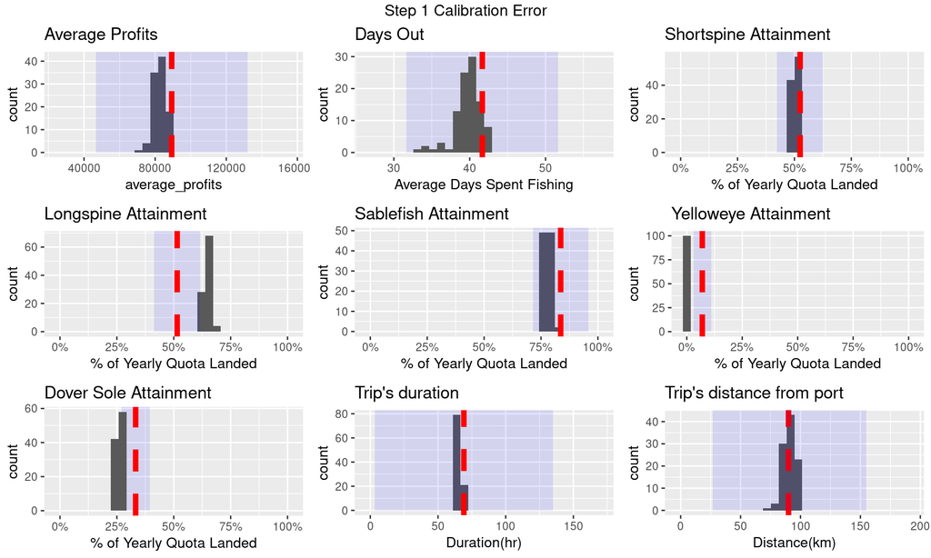

Figure 4.1: The histogram showing the fishing outcomes generated by 100 runs of statistically locked agents after the first step calibration. The red dashed line always represents the observed empirical mean while the blue area represents two standard deviations away from it

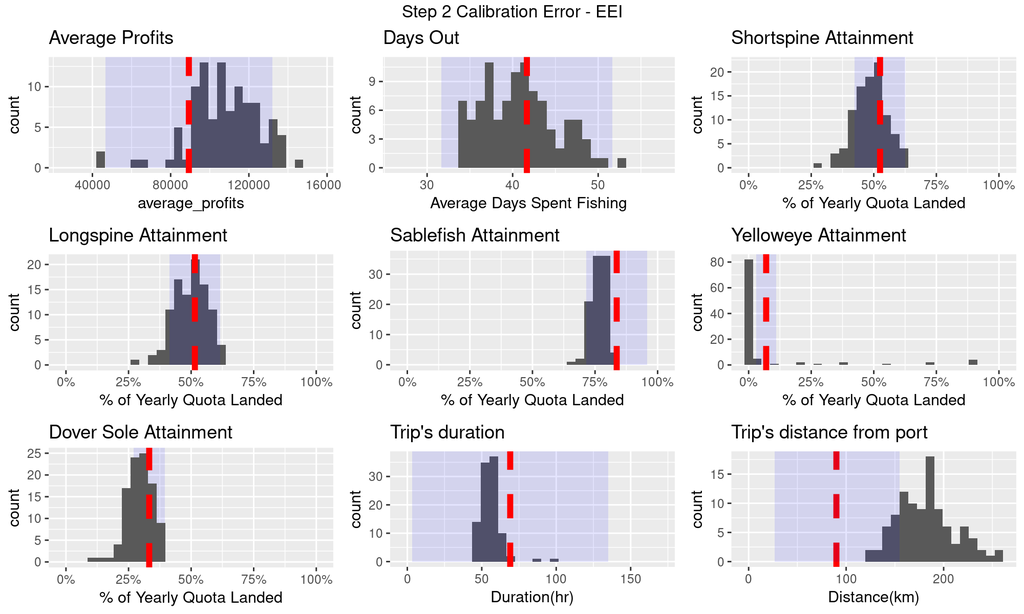

Figure 4.2: The histogram showing the fishing outcomes generated by 100 runs of the explore-exploit-imitate agents after being calibrated. The red dashed line always represents the observed empirical mean while the blue area represents two standard deviations away from it

After calibration, we rank each decision-making algorithm by their in-sample error. We run a set of 100 simulations for each of the fully calibrated 8 decision-making algorithms listed in section 3.3. We also run a set of simulations for the explore-exploit-imitate agent using exploration rate $\epsilon$ fixed at 20%, imitation rate $\gamma$ at 100% and exploration range $\delta$ of 5 cells. This has been our usual default assumption in previous applications of the model and we wanted to test its accuracy. We show this in figure 4.3.

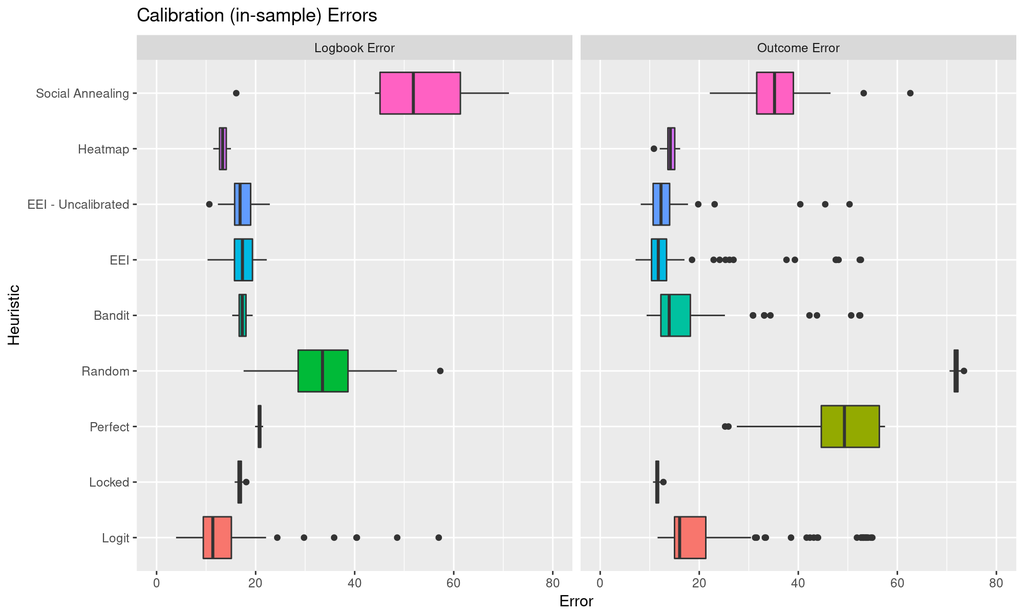

Figure 4.3: Box-plot showing the logbook and outcome errors for 100 runs of each decision-making algorithm.

Third, perfect agents fit data worse than adaptive agents. The issue with perfect agents is that they are too good at their job. Figure 4.4 shows that perfect agents achieve too much profits compared to reality. Figure 4.5 shows how perfect agents are unique in targeting yelloweye rockfish. Yelloweye rockfish is a very rare fish and its quota very limited. Most agents have a hard time finding it at all but if they do they see its quota prices rise enough to stop fishing it. Perfect agents instead like to target areas with yelloweye rockfish either at the very beginning or the very end of the fishing season. They do so perfectly and never fish out too much of the quota available. This makes sense from a purely risk-neutral decision maker perspective (which is reflected by perfect agents making higher profits) but it is not something that happens empirically.  
The outcome error penalizes rockfish landinds heavily because its magnitude in terms of percentage quota attainment is high even though by tonnage it amounts to only small catches.

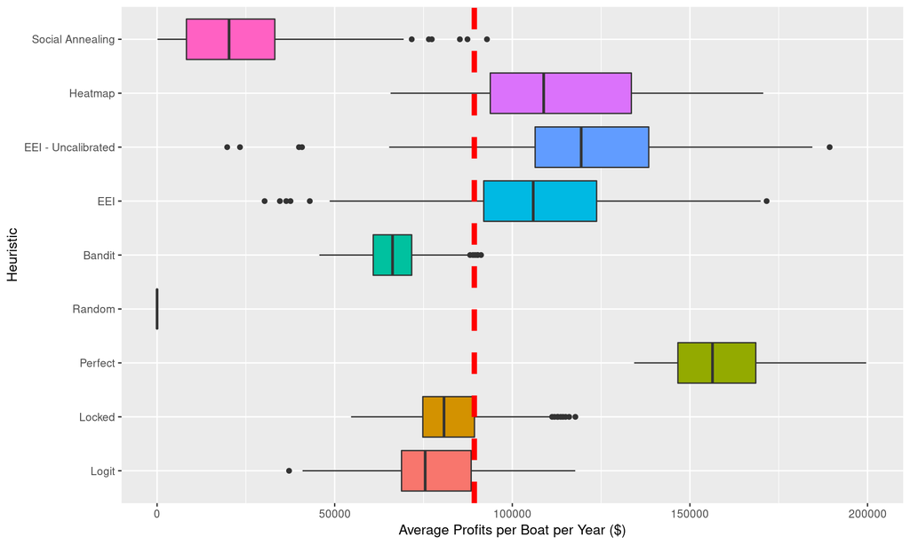

Figure 4.4: The average yearly profits generated by each decision making algorithm between 2011 and 2014. The observations are left censored: random agents only achieve negative profits or go entirely out of business and then achieve 0 profits overall. The red dashed line represents the empirically observed average yearly profits

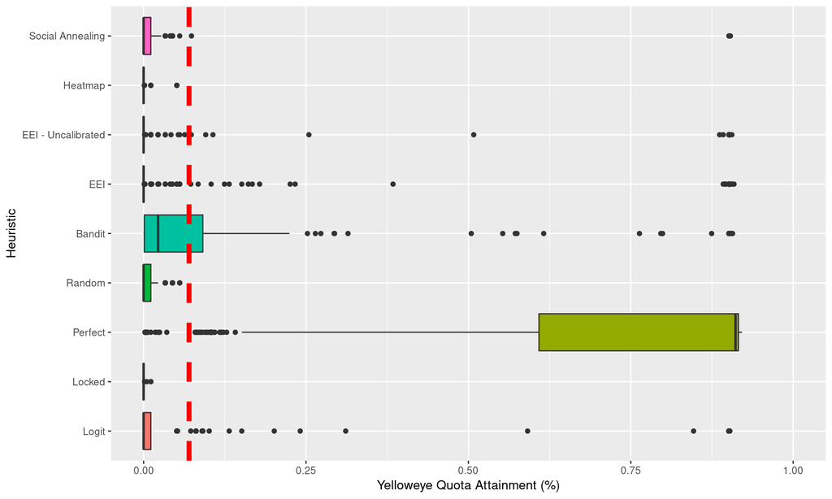

Figure 4.5: The average yelloweye quota attainment generated by each decision making algorithm between 2011 and 2014.

Fourth, the uncalibrated explore-exploit-imitate performs just as well as other calibrated adaptive agents. This is in part due to the resilience of explore-exploit-imitate to parameter changes as we show in section 6.1.

This section focused on in-sample errors. The next section will focus on out-sample predictions and will show that the overall results stand.

# 5 Validation

Validation here means testing the quality of out-of-sample predictions (Schulze et al. 2017 calls this “output corroboration”, but as noted in Augusiak, Van den Brink, and Grimm (2014) it is a procedure that goes by many names).  
We validate the model in three separate ways. First we use our model to predict what happened in 2015 (a year for which we have data but we haven’t calibrated for). Second, we look at our model predictions when we move the starting date to 2007 rather than 2011. Third, we look at other fishing outcomes we didn’t explicitly calibrate against.

## 5.1 Predicting 2015

In statistics, the ideal way to select and validate models is by leaving a part of the data out of the calibration phase and test the fully trained model in predicting it (see chapter 7 of Hastie and Tibshirani 2001).  
We calibrated the model with data from 2011 to 2014, we check here how it predicts 2015. One weakness of this approach here is that 2015 was not a particularly special year, fishing outcomes weren’t very different from the preceding years we calibrated against. Because our model outputs time series and its dynamics are non-stationary we cannot use other cross-validation techniques; we can only test the model by calibrating it up to a date and predicting the rest.

Our logbook data ends in 2014 but we still have landings and catcher-vessel-report observations so that 7 of the 9 fishing outcomes described in 2.2 are available for 2015. Define the validation error as the distance in standard deviations between real and simulated fishing outcomes for 2015:
$$\text{Validation Error} = \sum_i \frac{|y_{i,2015} - \hat y_{i,2015}|}{\sigma_i}$$
We rank each algorithm by this error in figure 5.1.

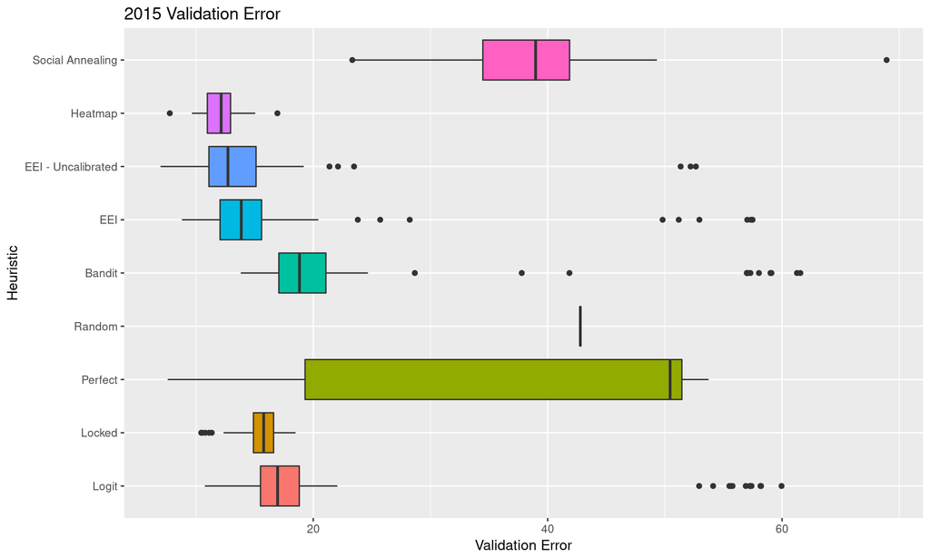

Figure 5.1: Box plot summarising 100 runs for each decision making algorithm, calibrated between 2011 and 2014 in their ability to predict 2015 fishing outcomes.

## 5.2 Earlier Start

Because our model runs only for a short amount of time, we incur the risk of calibrating the model too tightly around the few years for which we have data. In this section we test for this risk by starting the model in 2007 rather than 2011. This involves changing starting abundance for each species, different gas prices, variable costs and implementing the 2011 regulatory shock when a different set of quotas were introduced and made tradeable. We run the model again until 2015 without recalibrating it. We test its prediction of both the 2011-2014 period (calibration error) and 2015 (validation error).  
We plot the results in figure 5.2.

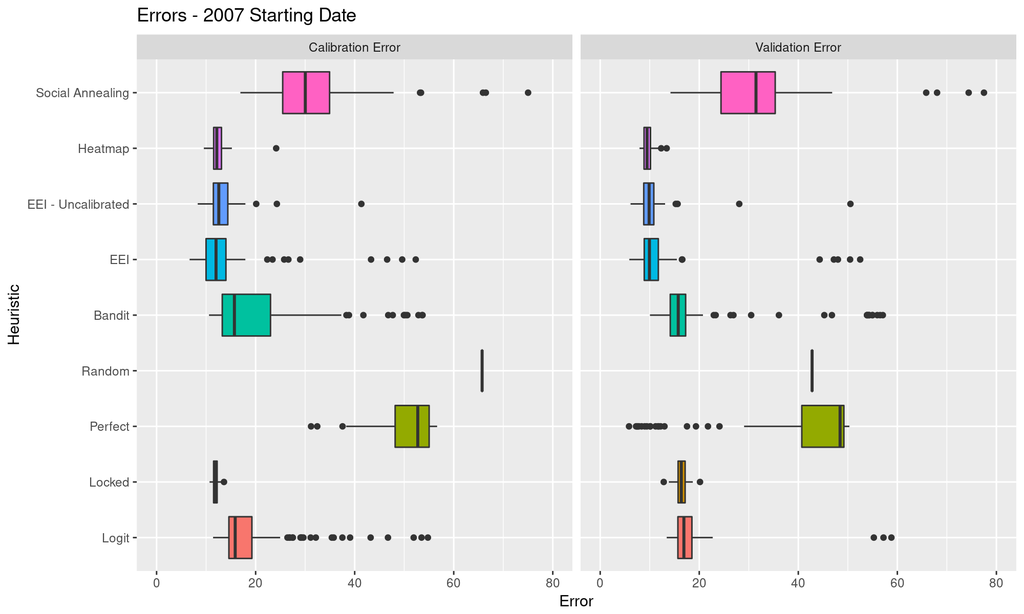

Figure 5.2: Box plot showing the fishing outcomes error for 100 simulations of each decision algorithm. Calibration error refers to 2011-2014 errors while validation error refers to 2015 prediction error

All the results from both the calibration and validation are upheld. Adaptive agents do better, statistical agents underperform in 2015, perfect agents catch too much yelloweye and finally bandit and social annealers fit worse than in the calibration phase.

## 5.3 Uncalibrated outputs

We can also test the quality of our model by looking at outputs we didn’t calibrate against (this approach is relatively common in macro-economics modelling, for an example looking at Euler equation fits see Canzoneri, Cumby, and Diba 2007). The issue is that we excluded these outputs from calibration because their quality was not very high, hence the comparisons in this section can only be qualitative.  
We show that while the number of fishers, the profit trend and the quota prices look accurate, fishing effort accumulates too much in south Oregon rather than north Oregon.  
We focus here on the four adaptive decision-making algorithms that best performed in the previous section (explore-exploit-imitate, bandit algorithms and heatmapping agents).

Figure 5.3 shows the simulated quota prices. Sablefish quota prices are high, as they ought to be given that it is the constraining species, but never above their sale price (4.32 $/kg). Thornyheads and Dover sole are very cheap since there are plenty of quotas available for them. Yelloweye quotas are the hardest to simulate: agents form their reservation prices based on their catch history and yelloweye are hardly ever caught. Empirically fishers hoard quotas on the fear of catching any but our model do not model this expectation. Whenever one or two boats do fish yelloweye rockfish however, quota prices explode as can be seen by the outlier prices being much higher than for all the other species.

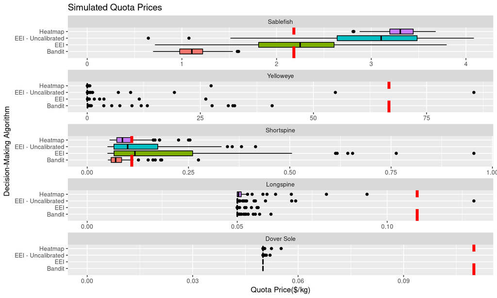

Figure 5.3: Five sets of box plots, one for each species’ quota prices. The box plots show the yearly average trade price over 100 simulated runs. The red line is the 2011-2014 average as in table 2 of Holland (2016)

As a second test we plot average daily profits over the years in figure 5.4. Data on profit trends from the FISHeries Economics Explorer dataset (Northwest Fisheries Science Center 2017) shows a peak in variable costs net revenue in 2011, then a slight decline until another peak in 2015. However the confidence intervals on the time series are much larger than the trend itself which make any inference and calibration suspicious. Our main focus here was to make sure there was no definite negative trend in profits over the years (which would not be consistent with data).

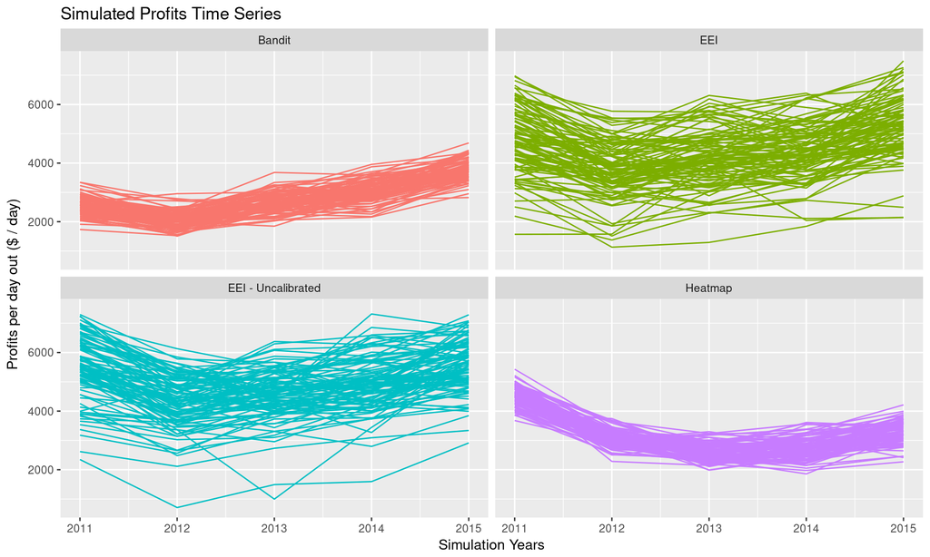

Figure 5.4: The simulated profits time series, one for each adaptive decision-making algorithm

As a third test we plot the number of fishers left in the simulation at the end of each year in figure 5.5. From the catcher vessel report we know the number of fishers remaining in the DTS fishery (Steiner et al. 2016), however these numbers change between each revision of the dataset. Moreover each year about 10-15% of boats in the West-Coast groundfish fishery make operating losses so that our simulated quitting decision (making two consecutive years of losses) might be overly stringent. Still, most simulations settle around the right number of fishers.

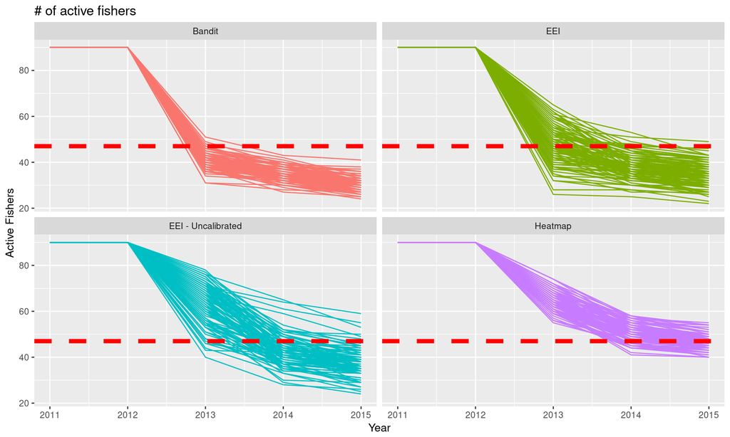

Figure 5.5: Number of active fishers left in each simulation each year. The dashed red line shows the number of non-withing DTS boats left by 2015.

Finally, we plot in figure 5.6 the active fishers per port at the beginning and at the end of the simulation when using explore-exploit-imitate agents. The geographical allocation of other adaptive algorithms is similar. The model tends to predict too few fishers in Astoria and too many in Newport and Coo’s Bay. The model however does predit the fall in DTS participation in Washington state and is also accurate in California.

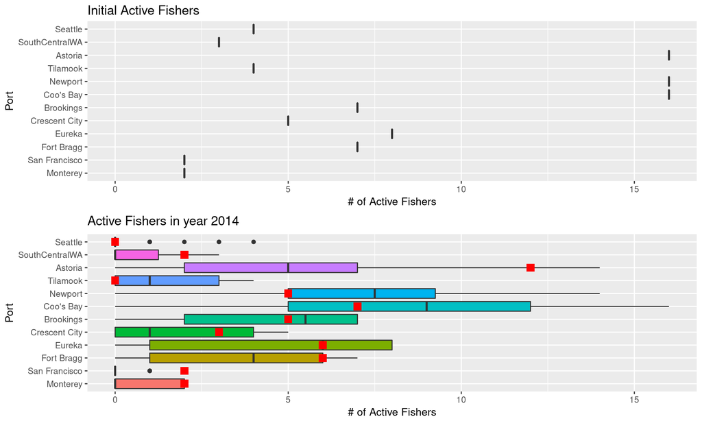

Figure 5.6: Box-plot of active fishers per port (ordered from north to south along the coast) when the decision-making algorithm is the calibrated explore-exploit-imitate over 100 simulated runs. The red squares in the 2014 plot are the active fishers per port reported by Steiner et al. (2016)

# 6 Sensitivity Analysis

In this section we show that the model is insensitive with respect to calibrated parameters, biology layer, movement of fish and regulation assumptions. It is however sensitive to changes in the initial distribution of fish and quota trading microstructure.

Windrum, Fagiolo, and Moneta (2007) classify sensitivity analysis into 3 groups. First, we need to test variability across runs due to the simulation’s stochasticity. We did so already in the previous sections by running each simulation 100 times. Second, we need to test the model sensitivity to the calibrated parameters. We do so in sections 6.1, section 6.5 and section 6.6. Third, we need to test the model sensitivity to inputs and initial conditions. We test our sensitivity to the biology layer in section 6.2, to the Essential Fish Habitat maps in section 6.3 and to regulation assumptions in section 6.4.

## 6.1 Active Non-Linear Tests

J. H. Miller (1998) introduces active non-linear tests as a search problem (see chapters 3-5 of Russell and Norvig 2002): look in the neighborhood of the optimal parameters for the worst possible outcome. In its original implementation a search around 10% neighborhood of calibrated parameters for the WORLD3 model (D. H. Meadows et al. 1972) delivered predictions completely at odds with the authors’ original claims. Stonedahl and Wilensky (2010) provides another example searching in the 10% neighborhood of the Anasazi model (see also J. S. Lee et al. 2015).  
Here we use active non-linear tests to study the sensitivity of our calibrated parameters.

We first perform an active non-linear test to the calibrated catchability ($Q$) and hold-size ($H$) parameters by varying them 10% around their optimal value. We show the histogram of fishing outcome error in figure 6.1. The search increases the error by only 9% on average. While the difference is significant to a wilcox test, it is linearly proportional to the 10% shock in parameters.

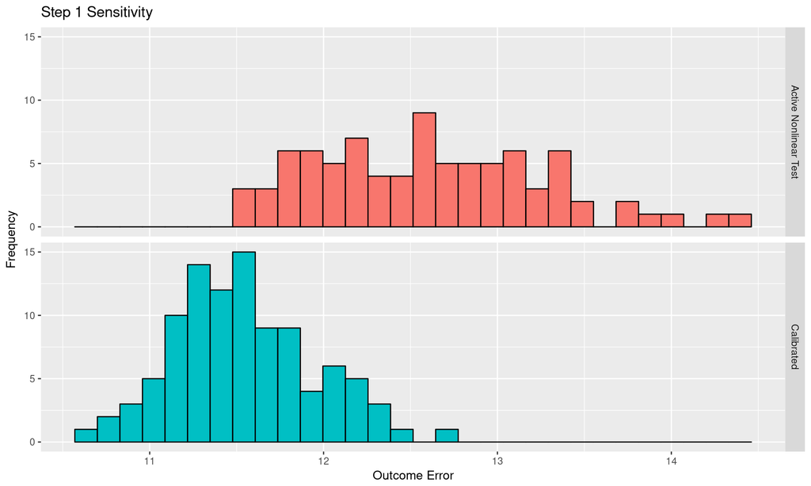

Figure 6.1: The histogram of fishing outcome errors generated by 100 runs of the step 1 calibrated model (that is, using statistically locked agents) at the bottom versus the worst performing set of parameters found by the active non-linear test.

We can also search in the 10% neighborhood of both catchability and behavioural parameters. The sensitivity to this search depends on the algorithm used. Here we show two: explore-exploit-imitate agents and heatmapping agents. Explore-exploit-imitate agents are very insensitive to parameter changes. In figure 6.2 we compare the calibrated and worst possible parameter sets (changing both catchability and behavioural parameters by at most 10%). The error is statistically significant to a Wilcoxon test, but the overall increase is only of 5%. Even though the explore-exploit-imitate sensitivity analysis has more parameters it is actually stabler the statistically locked agents used above.

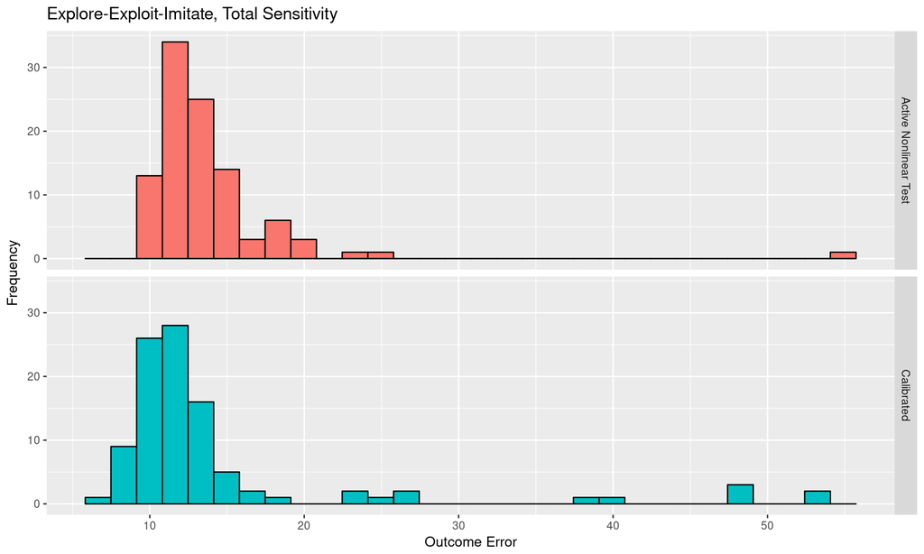

Figure 6.2: The histogram of fishing outcome errors generated by 100 runs of the step 2 calibrated model using explore-exploit-imitate at the bottom versus the worst performing set of parameters found by the active non-linear test.

Heatmapping agents are more sensitive to active non-linear tests (particularly to changes in forgetting factor $\lambda$). As shown in figure 6.3 the average fishing outcome error increases by almost 40%. In a way this is stating the obvious: heatmapping agents are more complex than explore-exploit-imitate ones and we expect them to be more delicate.

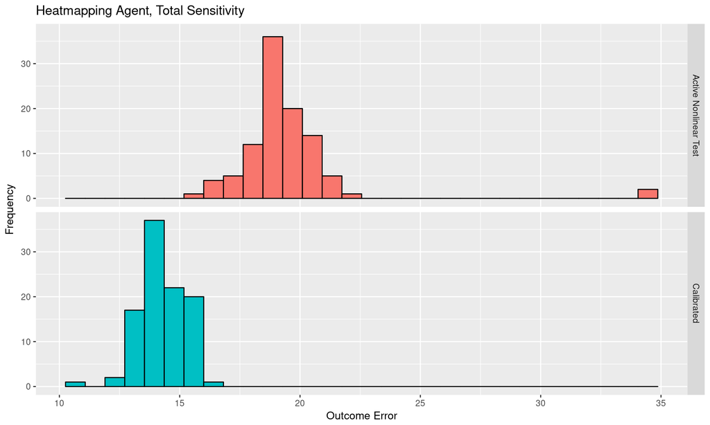

## 6.2 Deriso-Schnute

In this section we substitute the entire biological layer. The original biology layer is stock-assessment driven, age and sex structured (see section 3.1). It is a complicated mathematical system, each species is defined by 23 parameters plus selectivity ($s_i$) and retention ($r_i$) vectors. They represent the best operational model available but we need to test our model reliance on it.

In this section we impose a biomass-only Deriso-Schnute biology layer(as in Toft, Punt, and Little 2011). All the parameters are summarised in table 6.1. Gone is the abundance set of vectors: $\Big\{ A_{1,\text{male}},A_{1,\text{female}},A_{2,\text{male}},\dots,A_{5,\text{female}} \Big\}$ as each map cell now contains just the weight of the fish present in it. In vector form:
$$B =
\begin{bmatrix}
B_1\\
B_2\\
\vdots\\
B_5\\
\end{bmatrix}
=
\begin{bmatrix}
\text{Total weight of species } 1\\
\text{Total weight of species } 2\\
\vdots\\
\text{Total weight of species } 5\\
\end{bmatrix}$$

There is no selectivity or retention as catchability ($q_i$) now maps linearly between cell biomass and catches per hour:
$$\text{Catches of species } i = q_i B_i$$
Moreover fitting the Deriso-Schnute model to historical data on catches generates different starting (2011 or 2007) biomasses.

Table 6.1: All the parameters used for the Deriso-Schnute biology layer.

| Parameter | Sablefish | Yelloweye | Longspine | Shortspine | Dover Sole |
| --- | --- | --- | --- | --- | --- |
| Survival Rate | 0.92311 | 0.95504 | 0.895834135 | 0.950753929 | 0.914 |
| Maturity Age | 3 | 14 | 16 | 12 | 8 |
| Virgin Biomass (mt) | 527,154 | 8,883 | 103,038 | 331,900 | 853,954 |
| Rho | 0.813181971 | 0.98119423 | 0.92076 | 0.9999 | 0.965 |
| Steepness | .6 | 0.44056 | 0.6 | 0.6 | 0.8 |
| Weight at Recruitment (kg) | 1.03313 | 1.11910 | 0.167077312 | 0.091218379 | .314 |
| Weight at Pre-Recruitment | 0.63456 | 1.01604 | 0.154309183 | 0.074366689 | .2674 |

Figure 6.4 shows the validation errors for both starting dates (after recalibrating catchability $Q$ and hold-size $H$). All the general results still stand: adaptive agents do better than perfect agents, random agents do poorly and statistical agents degrade more when starting at the wrong date. The overall errors are higher, partially because this biology layer is less accurate than the original and partially because we did not re-calibrate the adaptive agents’ behavioural parameters.

Notice also how perfect agents tend to fit better with this biological layer. They still make too much profits but their tendency to target yelloweye is reduced. This is because while yelloweye is still rare, many more tows tends to catch miniscule amounts of it (a consequence of linear catchability and lack of rounding). This makes most agents reluctant to sell yelloweye quotas, making raids unpalatable to perfectly informed agents.

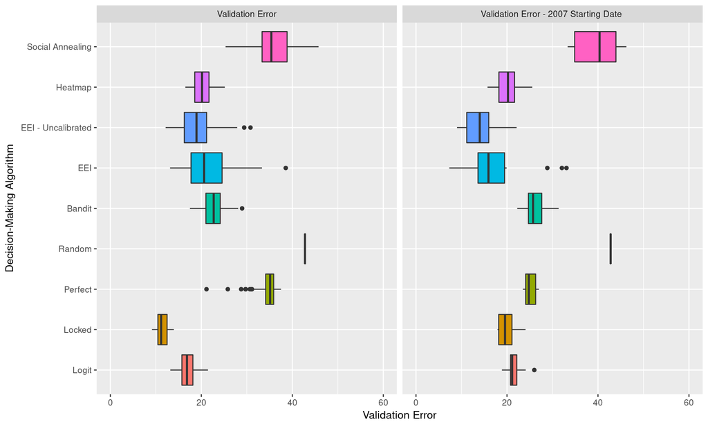

Figure 6.4: Box plots of validation errors for the recalibrated model using the Deriso-Schnute biology layer, both with 2011 and 2007 starting point.

Notice that while we replaced the biology layer, the rest of the model didn’t change. We designed POSEIDON to keep fleet and biology layers completely independent. We did so originally to be able to quickly apply the model to different areas, here however we show how the same design principle is useful for large-scale sensitivity analysis.

## 6.3 Geographical Distribution of Fish

In this section we change the distribution of fish while keeping the overall number and stock assessment-driven dynamics constant. We show that the model is sensitive to this change and that the main driver is the degree of smoothness by which fish is initially distributed.

Originally we distributed fish according to the Essential Fish Habitat statistical models; here we distribute fish proportional to the CPUE (catches per unit of effort) recorded in the logbook data for each statistical area.  
Branch et al. (2006) provides plenty of reasons not to use CPUE as an abundance metric and we only do so for sensitivity analysis.  
Logbook observations are sparse so we apply a linear interpolator to have a CPUE prediction for each cell of the map.

Figure 6.5 shows how the abundance of sablefish changes as we change data source. Because of the linear interpolation, the CPUE-derived map distributes fish much more smoothly.

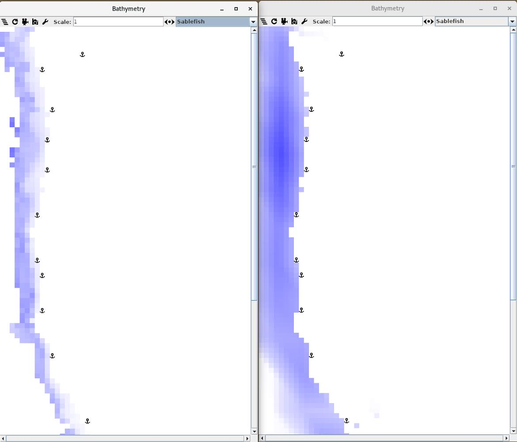

Figure 6.5: Image capture of abundance for sablefish in the model as derived from the EFH dataset (on the left) and the CPUE interpolation (on the right)

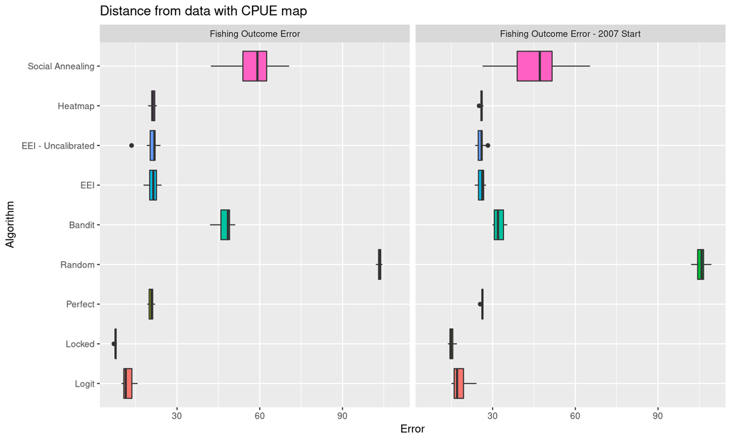

Figure 6.6: The calibration errors when using the CPUE map, each box plot represents 100 simulation runs.

All these results are due to the smoothness of geographical abundance. Figure 6.7 shows the profit simulated for each decision-making algorithm. The figure makes clear that it is not the profit maximizer agent that got more realistic, it is adaptive agents that now also make too much money. Smooth abundance distribution generates smooth profit curves that are easy for all adaptive agents to climb. When the problem is easy, assuming adaptive agents is like assuming perfect agents. Statistical agents perform well because they do not take advantange of the easier problem: they are forced to repeat historical choices even if better alternatives are present.

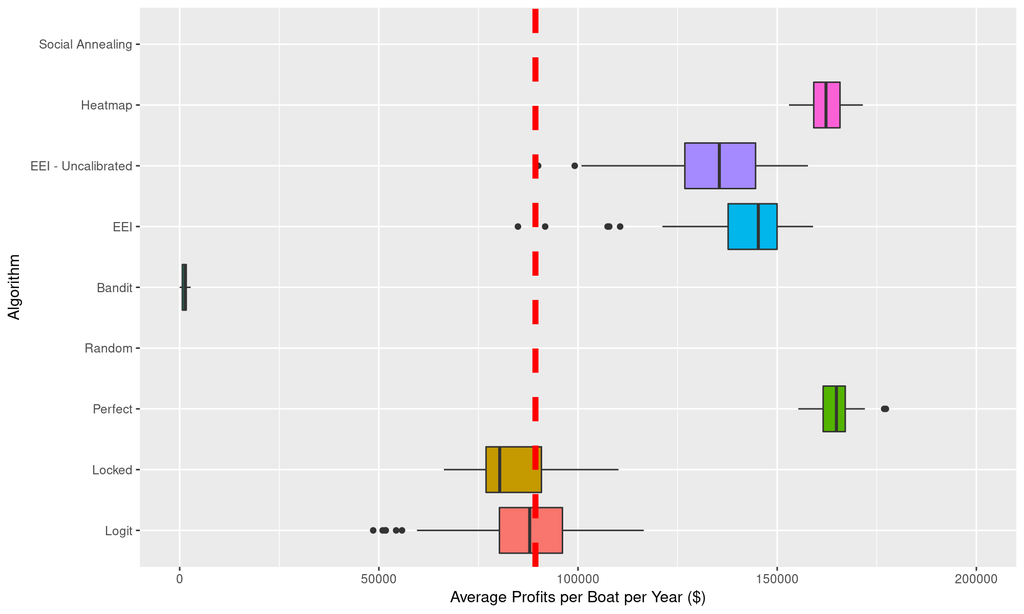

Figure 6.7: Yearly profits made by each decision-making algorithm in 100 simulated runs. Red dashed line is the empirical 2011-2014 average

It is instructive to look in detail at the consequences of using CPUE-driven maps. One subtle property of the map is shortspine and sablefish being almost perfectly co-located, as shown in figure 6.8, below. This has less to do with the two species being actually co-located and instead simply represents the efficiency of fishermen in Astoria (a good reason for not using CPUE-driven maps). The model reacts in a realistic way: because sablefish is the target species and it is now impossible landing it without catching shortspine as well, shortspine quotas become more expensive; as we show in figure 6.9 quotas are sometimes even traded at prices higher than shortspine’s worth, meaning that agents take a loss by landing shortspine just so that they can land sablefish as well.

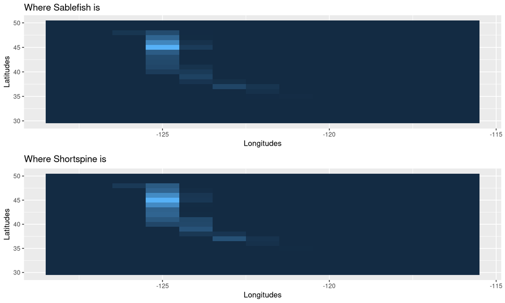

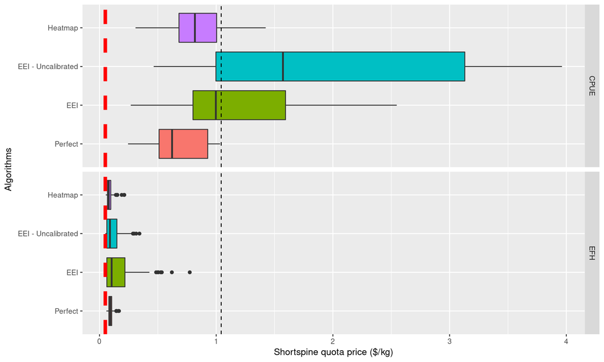

Figure 6.9: Shortspine quota prices traded for each simulation using either EFH or CPUE abundance maps. The red dashed line represents the empirical quota price observed, the dashed black line represents the ex-vessel price. With the CPUE-driven map we see not only quotas more expensive than what was empirically observed but sometimes more expensive than their sale prices

## 6.4 Quota Variant

In reality regulators split sablefish quota markets in two: north of the 36th parallel and south of it. In our simulation we combined the two into a single quota. In practice however DTS boats participated exclusively in the north quota market. Here we include that knowledge by removing sablefish south quota from the total available in the model. This may make the model more accurate but does so by adding post-hoc knowledge.

Figure 6.10 shows the calibration and validation errors for each decision making algorithm. Again, random agents do poorly as do perfect agents. Again adaptive agents do well but do not overtake statistically locked agents.

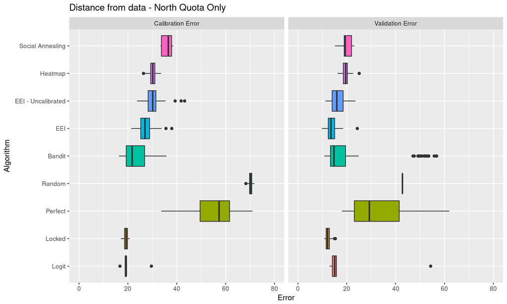

Figure 6.10: The box-plot of 100 simulations for each decision making algorithm with fishing outcome error (2011-2014) and validation error (2015 prediction)

## 6.5 Movement

From Alaskan tagging data we know sablefish moves on average 191 km per year (Hanselman et al. 2015). We also know from simple abstract model runs that fish diffusion rate in POSEIDON have large effects on long term profitability and behaviour of the simulated fleet. For these reasons we initially classed sablefish movement as a free parameter to calibrate much like catchabilities and hold-sizes. In these early calibration runs however movement rate did not have a significant effect in minimizing distance from data (which in a Bayesian optimization can be noticed by the very large bandwitdhs assigned to the variable by the optimiser or just by plotting posteriors). In the final version of the calibration presented above the movement rate was simply set to 0 as it made the model much faster to run.

Similar to Goethel et al. (2011), we modeled movement as a simple diffusion rate between cells. However, we biased movement in such a way that it would never alter the patchiness of the original map. Movement in this simulation isn’t from cells where there are more fish to cells where there are a few; rather fish moves from “full” areas to “empty” ones where full and empty are defined in terms initial abundance distribution. To make a concrete example, take cell A and a contiguous cell B where cell A contained $k_a$ percent of the total sablefish at the beginning of the simulation and cell B contained $k_b$ percent. If there currently are $f_a$ sablefish in cell A and $f_b$ in cell B, then fish movement between A and B is given by:
$$m \frac{f_a k_b - f_b k_a}{k_a+k_b}$$
where $m \in [0,1]$ is the diffusion rate parameter. This means that even at maximum movement rate distribution of fish remains as patchy.

Figure 6.11 shows the difference in error generated by maximizing sablefish diffusion rate. The calibration error increases (compared to the baseline scenario where fish do not move at all) by 9%. While we know that POSEIDON is sensitive to movement rates in other scenarios here we showed that when simulating short periods of time there is little error added by ignoring movement and it is anyway hard to back out a proper movement rate from data without longer observations.

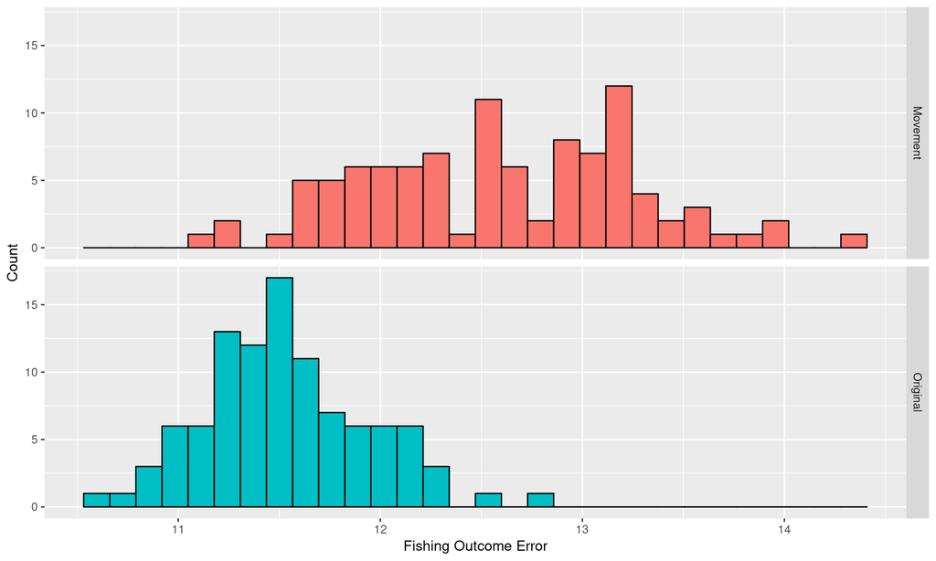

Figure 6.11: Comparison between aggregate errors after step 1 calibration (in blue) and the same errors with the same parameters except $m=1$ for sablefish (in red)

## 6.6 Trading

In our model, the ITQ system functions as a stock-market with agents posting bids and asks around their reservation prices and activating all crossing quotes. Our calibration is sensitive to this assumption. To show this, we ran the same calibrated parameters where the only difference was that the ITQ market allowed only 500kg of quotas for each species to be traded for each fisher. This is a crude representation of physical limits to matching and trading. This change alone increased error by 40% (see figure 6.12).

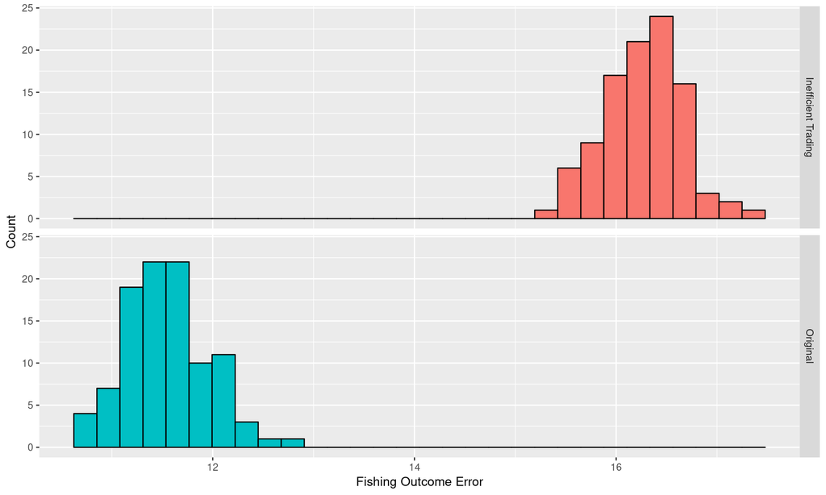

# 7 Weaknesses

We built the simplest possible model that could deal with data. Keeping a model simple reduces free parameters and degrees of freedom, but targeting simplicity is just one possible heuristic (Edmonds and Moss 2005). We achieved this simplicity by ignoring many idiosyncracies of the west coast groundfish fishery.

First, we did not fully model boats’ heterogeneity. We focused on endogenous heterogeneity(as defined in LeBaron 2002): agents develop different life trajectories, use different experiences to build catch expectations that inform their demand for quotas which in turn leads to different experiences. Some differences however are exogeneous: some fishers have larger boats or better access to capital than others. We did not model these differences.

We did not model the entire value chain for groundfish (as Cooper and Jarre 2017 do in their Hake fishery model, for example). In our model boats are price-takers facing an infinitely elastic demand. While the processing sector downstream is concentrated we did not model its monopoly power. Fishers in our model pick where and what to target without bargaining with their buyers.

In our model fishers face only a simplified cost structure. In reality crew and captains in the DTS fishery are in part paid a share of the revenue (see chapter 10 of Steiner et al. 2016); buyback fees are paid as a percentage of landings while observers are paid in 24 hour increments. We subsumed all these into an hourly variable cost. This makes the model easier to understand but prevents us from studying, for example, what would be the effect of switching observers payment to a flat per-pound landing fee.

We assumed catchability to be fixed in our model; if agents want to change their catch composition they must pick a different cell to fish from. This assumption may be too restrictive, even within the limited time span of our model. S. J. Miller and Deacon (2017) shows that besides changing location, some fishers may be fishing more at night or make shorter trawls to avoid bycatch.

We did not implement the ability of fishers to change home port. In our model agents may quit the fishery but are otherwise tied to their port. We chose this because every port in the DTS fishery has fewer boats in 2014 than in it had 2011, making calibration impossible. In the long term however it is possible that those who survive may move to more profitable areas.

We assumed all agents as profit maximizers. Klein, Barbier, and Watson (2017) however reports that consistency, sustainability and neighbourliness may be just as important in this fishery. While all the decision making algorithms we presented can be adapted to maximize utility rather than profits we did not pursue this here.

# 8 Conclusions

This was the first application of our model to a real fishery. The DTS (Dover-thornyhead-sablefish) fishery is special for its data availability, complete observer coverage and small size. It provided the right benchmark to test the quality of our decision-making algorithm and model more broadly. It is clear to us however that future applications will not provide all these luxuries.

One key result of our simulation is the poor performance of perfectly rational agents. The issue with perfect agents is one of proportions. In Toft, Punt, and Little (2011) and Kaplan, Holland, and Fulton (2014) where the agents are port groups and geography is coarse, it is probably perfectly fine to assume agents coarsely perfect. It is with higher resolution models that this assumption starts generating unrealistic patterns (in our case, perfect risk-free raids into yelloweye areas).

The lesson learned from this observation is however ambiguous. On the one hand we showed that simpler decision-making algorithms fit and predict better in this higher-resolution model. On the other hand we did not test “even more perfect” agents: an infinitely rational agent may predict ahead of time what others will do and prempt certain behaviours (for example by increasing the sale price of yelloweye quota in anticipation of raids).

It is still impossible to generalize these results. We will need to perform this exercise over multiple fisheries differing in gear, regulations and biology to know the limits of what we discovered here. Moreover we will need to cross-check our simulation results with more traditional surveys. It must be possible to ask actual skippers how much they think each decision-making algorithm describes their behaviour.

## Bibliography

Abbott, Joshua K, and James E Wilen. 2011. “Dissecting the tragedy: a spatial model of behavior in the commons.” *Journal of Environmental Economics and Management* 62 (3). Elsevier: 386–401.

Allen, P M, and J M McGlade. 1986. “Dynamics of discovery and exploitation: The case of the Scotian Shelf groundfish fisheries.” *Canadian Journal of Fisheries and Aquatic Sciences* 43 (6). NRC Research Press Ottawa, Canada: 1187–1200. doi:10.1139/f86-148.

Augusiak, Jacqueline, Paul J. Van den Brink, and Volker Grimm. 2014. “Merging validation and evaluation of ecological models to ’evaludation’: A review of terminology and a practical approach.” *Ecological Modelling* 280 (May). Elsevier: 117–28. doi:10.1016/j.ecolmodel.2013.11.009.

Badham, Jennifer, Chipp Jansen, Nigel Shardlow, and Thomas French. 2017. “Calibrating with Multiple Criteria: A Demonstration of Dominance.” *Journal of Artificial Societies and Social Simulation* 20 (2). JASSS: 11. doi:10.18564/jasss.3212.

Bastardie, Francois, J. Rasmus Nielsen, Bo Sølgaard Andersen, and Ole Ritzau Eigaard. 2013. “Integrating individual trip planning in energy efficiency - Building decision tree models for Danish fisheries.” *Fisheries Research* 143: 119–30. doi:10.1016/j.fishres.2013.01.018.

Beecham, J. A., and G. H. Engelhard. 2007. “Ideal free distribution or dynamic game? An agent-based simulation study of trawling strategies with varying information.” *Physica A: Statistical Mechanics and Its Applications* 384 (2). North-Holland: 628–46. doi:10.1016/j.physa.2007.05.053.

Bellman, Marlene A., and Eliza Heery. 2013. “Discarding and fishing mortality trends in the U.S. west coast groundfish demersal trawl fishery.” *Fisheries Research* 147. Elsevier: 115–26. doi:10.1016/j.fishres.2013.04.007.

Bellman, Marlene A., Scott Heppell, and Chris Goldfinger. 2005. “Evaluation of a US west coast groundfish habitat conservation regulation via analysis of spatial and temporal patterns of trawl fishing effort.” *Canadian Journal of Fisheries and Aquatic Sciences* 62 (12). NRC Research Press: 2886–2900.

Branch, Trevor A, Ray Hilborn, Alan C Haynie, Gavin Fay, Lucy Flynn, Jennifer Griffiths, Kristin N Marshall, et al. 2006. “Fleet dynamics and fishermen behavior: lessons for fisheries managers.” *Canadian Journal of Fisheries and Aquatic Sciences* 63 (7): 1647–68. doi:10.1139/f06-072.

Bubeck, Sébastien, and Nicolò Cesa-Bianchi. 2012. “Regret Analysis of Stochastic and Nonstochastic Multi-armed Bandit Problems.” doi:10.1561/2200000024.

Canzoneri, Matthew B., Robert E. Cumby, and Behzad T. Diba. 2007. “Euler equations and money market interest rates: A challenge for monetary policy models.” *Journal of Monetary Economics* 54 (7). Elsevier: 1863–81. doi:10.1016/j.jmoneco.2006.09.001.

Cenek, Martin, and Maxwell Franklin. 2017. “An adaptable agent-based model for guiding multi-species Pacific salmon fisheries management within a SES framework.” *Ecological Modelling* 360 (September): 132–49. doi:10.1016/j.ecolmodel.2017.06.024.

Cooper, Rachel, and Astrid Jarre. 2017. “An Agent-based Model of the South African Offshore Hake Trawl Industry: Part I Model Description and Validation.” *Ecological Economics* 142: 268–81. doi:10.1016/j.ecolecon.2017.06.026.

Edmonds, Bruce, and Scott Moss. 2005. “Multi-Agent and Multi-Agent-Based Simulation.” *Multi-Agent and Multi-Agent-Based Simulation* 3415. Springer, Berlin, Heidelberg: 130–44. doi:10.1007/b106991.

Fulton, Elizabeth A., Jason S Link, Isaac C. Kaplan, Marie Savina‐Rolland, Penelope Johnson, Cameron Ainsworth, Peter Horne, Rebecca Gorton, Robert J Gamble, and Anthony D M Smith. 2011. “Lessons in modelling and management of marine ecosystems: the Atlantis experience.” *Fish and Fisheries* 12 (2). Wiley Online Library: 171–88.

Gourieroux, C., A. Monfort, and E. Renault. 1993. “Indirect Inference.” *Journal of Applied Econometrics* 8. Wiley: 85–118. doi:10.2307/2285076.

Grimm, Volker, Eloy Revilla, Uta Berger, Florian Jeltsch, Wolf M Mooij, Steven F Railsback, Hans-Hermann Thulke, Jacob Weiner, Thorsten Wiegand, and Donald L DeAngelis. 2005. “Pattern-oriented modeling of agent-based complex systems: lessons from ecology.” *Science* 310 (5750). American Association for the Advancement of Science: 987–91.

Hanselman, Dana H., Jonathan Heifetz, Katy B. Echave, Sherri C. Dressel, and Josef Michael Jech. 2015. “Move it or lose it: movement and mortality of sablefish tagged in Alaska.” *Canadian Journal of Fisheries and Aquatic Sciences* 72 (2). NRC Research Press: 238–51. doi:10.1139/cjfas-2014-0251.

Hastie, T, and R Tibshirani. 2001. *The elements of statistical learning*. Vol. 1. Springer series in statistics Springer, Berlin. http://crmtview.asc.ohio-state.edu/currofc/docs/115/Stat 760 Syllabus.pdf.

Hicks, Allan C, and Chantell Wetzel. 2011. “The status of Dover sole (Microstomus pacificus) along the US West Coast in 2011.” *Portland: Pacific Fishery Management Council*.

Holland, Daniel S. 2016. “Development of the Pacific Groundfish Trawl IFQ Market.” *Marine Resource Economics* 31 (4): 453–64. doi:10.1086/687829.

Holland, Daniel S., and Jon G. Sutinen. 2000. “Location Choice in New England Trawl Fisheries: Old Habits Die Hard.” *Land Economics* 76 (1): 133. doi:10.2307/3147262.

Hunt, Len M. 2005. “Recreational fishing site choice models: insights and future opportunities.” *Human Dimensions of Wildlife* 10 (3). Taylor & Francis: 153–72.

Hunt, Len M., Barry N. Boots, and Peter C. Boxall. 2007. “Predicting Fishing Participation and Site Choice While Accounting for Spatial Substitution, Trip Timing, and Trip Context.” *North American Journal of Fisheries Management* 27 (3). Taylor & Francis Group: 832–47. doi:10.1577/M06-079.1.

Janssen, Marco A. 2009. “Understanding Artificial Anasazi.” *Journal of Artificial Societies and Social Simulation* 12 (4): 13. doi:13.

Kaplan, Isaac C., Daniel S. Holland, and Elizabeth A. Fulton. 2014. “Finding the accelerator and brake in an individual quota fishery: Linking ecology, economics, and fleet dynamics of US West Coast trawl fisheries.” *ICES Journal of Marine Science* 71 (2): 308–19. doi:10.1093/icesjms/fst114.

Klein, E S, M R Barbier, and J R Watson. 2017. “The dual impact of ecology and management on social incentives in marine common-pool resource systems.” doi:10.1098/rsos.170740.

Krzyzak, Adam. 1992. “Global Convergence of the Recursive Kernel Regression Estimates with Applications in Classification and Nonlinear System Estimation.” *IEEE Transactions on Information Theory* 38 (4): 1323–38. doi:10.1109/18.144711.

Kuleshov, Volodymyr, and Doina Precup. 2014. “Algorithms for multi-armed bandit problems.” doi:10.1145/1109557.1109659.

LeBaron, Blake. 2002. “Short-memory traders and their impact on group learning in financial markets.” *Proceedings of the National Academy of Sciences of the United States of America* 99 Suppl 3 (suppl 3). National Academy of Sciences: 7201–6. doi:10.1073/pnas.072079699.

Lee, Ju Sung, Tatiana Filatova, Arika Ligmann-Zielinska, Behrooz Hassani-Mahmooei, Forrest Stonedahl, Iris Lorscheid, Alexey Voinov, Gary Polhill, Zhanli Sun, and Dawn C. Parker. 2015. “The complexities of agent-based modeling output analysis.” *Journal of Artificial Societies and Social Simulation* 18 (4). doi:10.18564/jasss.2897.

Lian, C, R Singh, and Quinn Weninger. 2009. “Fleet restructuring, rent generation, and the design of individual fishing quota programs: Empirical evidence from the Pacific Coast groundfish fishery.” *Marine Resource Economics* 24: 329–59. doi:10.2307/42629661.

Meadows, Donella H, Dennis L Meadows, Jorgen Randers, and William W Behrens. 1972. “The limits to growth.” *New York* 102: 27.

Miller, J. H. 1998. “Active Nonlinear Tests (ANTs) of Complex Simulation Models.” *Management Science* 44 (6): 820–30. doi:10.1287/mnsc.44.6.820.

Miller, Steve J., and Robert T. Deacon. 2017. “Protecting Marine Ecosystems: Regulation Versus Market Incentives.” *Marine Resource Economics* 32 (1). University of Chicago PressChicago, IL: 83–107. doi:10.1086/689214.

National Marine Fisheries Service. 2009. “Pacific Coast Groundfish Fishery, Trip limit Tables for January 1, 2010.” Seattle, WA: NMFS.

———. 2013. “Groundfish essential fish habitat synthesis: a report to the pacific fishery management council.” April. Seattle, WA: NOAA NMFS Northwest Fisheries Science Center.

———. 2017. “Shorebased IFQ Sector Balances.” https://www.webapps.nwfsc.noaa.gov/apex/ifq/f?p=155:1::::

Northwest Fisheries Science Center. 2017. “FISHeries Economics Explorer (FISHEye).” https://dataexplorer.northwestscience.fisheries.noaa.gov/fisheye/.

O’Hagan, A. 2006. “Bayesian analysis of computer code outputs: A tutorial.” *Reliability Engineering and System Safety* 91 (10-11): 1290–1300. doi:10.1016/j.ress.2005.11.025.

Oreskes, N, K Shrader-Frechette, and K Belitz. 1994. “Verification, Validation, and Confirmation of Numerical Models in the Earth Sciences.” *Science* 263 (5147). American Association for the Advancement of Science: 641–46. doi:10.1126/science.263.5147.641.

Parry, Hazel R., Christopher J. Topping, Marc C. Kennedy, Nigel D. Boatman, and Alistair W.A. Murray. 2013. “A Bayesian sensitivity analysis applied to an Agent-based model of bird population response to landscape change.” *Environmental Modelling and Software* 45 (July): 104–15. doi:10.1016/j.envsoft.2012.08.006.

Richiardi, Matteo, Roberto Leombruni, Nicole Saam, Michele Sonnessa, Artificial Societies, and Social Simulation. 2006. “A Common Protocol for Agent-Based Social Simulation.” *Journal of Artificial Societies and Social Simulation* 9 (1). JASSS. http://jasss.soc.surrey.ac.uk/9/1/15.html.

Rose, Kenneth A, Jerome Fiechter, Enrique N Curchitser, Kate Hedstrom, Miguel Bernal, Sean Creekmore, Alan Haynie, Shin-ichi Ito, Salvador Lluch-Cota, and Bernard A Megrey. 2015. “Demonstration of a fully-coupled end-to-end model for small pelagic fish using sardine and anchovy in the California Current.” *Progress in Oceanography* 138. Elsevier: 348–80.

Russell, Stuart J, and Peter Norvig. 2002. “Artificial intelligence: a modern approach (International Edition).” Prentice Hall.

Saul, Steven Eugene. 2012. “An Individual-based Model to Evaluate the Effect of Fisher Behavior on Reef Fish Catch Per Unit Effort.”

Schulze, Jule, Birgit Müller, Jürgen Groeneveld, and Volker Grimm. 2017. “Agent-Based Modelling of Social-Ecological Systems: Achievements, Challenges, and a Way Forward.” *Journal of Artificial Societies and Social Simulation* 20 (2). JASSS: 8. doi:10.18564/jasss.3423.

Shahriari, Bobak, Kevin Swersky, Ziyu Wang, Ryan P. Adams, and Nando De Freitas. 2016. “Taking the human out of the loop: A review of Bayesian optimization.” *Proceedings of the IEEE* 104 (1): 148–75. doi:10.1109/JPROC.2015.2494218.

Shelton, Andrew Olaf, James T Thorson, Eric J Ward, and Blake E Feist. 2014. “Spatial semiparametric models improve estimates of species abundance and distribution.” *Canadian Journal of Fisheries and Aquatic Sciences* 71 (11). NRC Research Press: 1655–66.

Shepperson, Jennifer, Lee G. Murray, Steven Mackinson, Ewen Bell, and Michel J. Kaiser. 2016. “Use of a choice-based survey approach to characterise fishing behaviour in a scallop fishery.” *Environmental Modelling and Software* 86 (December): 116–30. doi:10.1016/j.envsoft.2016.09.013.

Simon, Herbert A. 1997. *The sciences of the artificial, (third edition)*. 3rd ed. Vol. 33. 5. The {MIT} Press. doi:10.1016/S0898-1221(97)82941-0.

Snoek, Jasper, Hugo Larochelle, and Ryan P Adams. 2012. “Practical bayesian optimization of machine learning algorithms.” In *Advances in Neural Information Processing Systems*, 2951–9.

Somers, K.A., Y.W. Lee, J.E Jannot, and McVeigh J. 2016. “Catch tables by sector: Individual fishing quotas trawl and fixed gear, 2011-2015.” Seattle, WA: NOAA Fisheries, NWFSC Observer Program. http://www.nwfsc.noaa.gov/research/divisions/fram/observation/data{\_}products/sector{\_}products.cfm{\#}obs.

Steiner, Erin, Lisa Pfeiffer, Abigail Harley, Marie Guldin, and Todd Lee. 2016. “Economic Data Collection Program Catcher Vessel Report (2009–2014).” Seattle, WA: NOAA NWFSC.

Stephens, Andi, and Ian G Taylor. 2013. “Stock assessment and status of longspine thornyhead (Sebastolobus altivelis) off California, Oregon and Washington in 2013.” *Pacific Fisheries Management Council, Seattle, Washington* 123.

Stewart, Ian J., James T. Thorson, and Chantell Wetzel. 2011. “Status of the US sablefish resource in 2011.” *Portland: Pacific Fishery Management Council*.

Stonedahl, Forrest, and Uri Wilensky. 2010. “Evolutionary Robustness Checking in the Artificial Anasazi Model.” In *AAAI Fall Symposium: Complex Adaptive Systems*, 120–29.

Stow, Craig A., Jason Jolliff, Dennis J. McGillicuddy, Scott C. Doney, J. Icarus Allen, Marjorie A.M. Friedrichs, Kenneth A. Rose, and Philip Wallhead. 2009. “Skill assessment for coupled biological/physical models of marine systems.” *Journal of Marine Systems* 76 (1-2): 4–15. doi:10.1016/j.jmarsys.2008.03.011.

Taylor, Ian G, and Andi Stephens. 2013. “Stock Assessment of Shortspine Thornyhead in 2013.” *Portland: Pacific Fishery Management Council*.

Taylor, Ian G, and Chantell Wetzel. 2011. “Status of the US yelloweye rockfish resource in 2011 (Update of 2009 assessment model).” *National Oceanic and Atmospheric Administration, National Marine Fisheries Service*.

Toft, Jodie E., Andr E. Punt, and L. Richard Little. 2011. “Modelling the economic and ecological impacts of the transition to individual transferable quotas in the multispecies US west coast groundfish trawl fleet.” *ICES Journal of Marine Science* 68 (7). Pacific Fisheries Management Council, Seattle: 1566–79. doi:10.1093/icesjms/fsr095.

Uusitalo, Laura, Annukka Lehikoinen, Inari Helle, and Kai Myrberg. 2015. “An overview of methods to evaluate uncertainty of deterministic models in decision support.” Elsevier. doi:10.1016/j.envsoft.2014.09.017.

Vermorel, Joannes, and Mehryar Mohri. 2005. “Multi-Armed Bandit Algorithms and Empirical Evaluation BT - Machine Learning: ECML 2005.” In *Machine Learning: ECML 2005*, 437–48. Springer. doi:10.1007/11564096_42.

Windrum, Paul, Giorgio Fagiolo, and Alessio Moneta. 2007. “Empirical Validation of Agent  Based Models : Alternatives and Prospects.” *Journal of Artificial Societies and Social Simulation* 10 (2). Journal of Artificial Societies; Social Simulation: 1–21. doi:Article.

Zhao, Linqiao. 2010. “A model of limit-order book dynamics and a consistent estimation procedure.” Carnegie Mellon University.